# Wine Quality Data Project

Anant Jain, Eddie Lim, Joanas Tan, Rishav Koirala

11/11/2020

### Introduction

**Research Question**  
Can we predict with good accuracy the quality of wine for both the red and the white varieties by considering their chemical properties, and identify the most significant features that predict a good red wine or white wine?

**Research Approach**  
To answer the research question, we will undertake the following approach:

1. First, we will carry out Exploratory Data Analysis (EDA) on our datasets. This helps us to make decisions in building our classifers by examining what the data suggests, such as by looking if the chemical compounds appear to be different between the types of wine for example, and if the variables are correlated.

This is done by:  
* Representing each variable as a boxplot  
* Scatterplot matrix

2. Second, we will then build our classifiers which we will use to predict the quality of the wine. We will label the wine as `good` if it is above the median value of 6, and the wine as `bad` if it is equal to or lower than 6. Since this is a binary response variable, there are three suitable classifiers we have learnt which are:
- Logistic Regression
- Decision Tree
- Naive Bayes

Thus, we will build each of the classifer, evaluate their performance by looking at their ROC plots, as well as their AUC values, and then decide on which classifier is best suited to predict wine quality.

3. Finally, we will also perform stepwise regression to identify what the most significant features are in predicting wine quality by performing stepwise regression.

### Preparing the data

```r
data_redwine <- read.csv("winequality-red.csv")
data_whitewine <- read.csv("winequality-white.csv")
```

### Exploratory Data Analysis (EDA)

First, we need to see if the red and the white wine data are significantly differnt from each other. To this end, we utilize two methods: k-means clustering and Principal Means Analysis (PCA)

Before that, we temporarily label the data as red or wine by adding an additional column to the datasets.

```r
data_redwine$label <- rep("red", nrow(data_redwine))
data_whitewine$label <- rep("white", nrow(data_whitewine))

total <- rbind(data_redwine, data_whitewine)
total <- na.omit(total)
```

**Using k-means clustering to attempt to classify the total wine dataset**

```r
kmdata <- as.matrix(total[c("fixed.acidity", "volatile.acidity", "citric.acid",
"residual.sugar", "chlorides", "free.sulfur.dioxide", "total.sulfur.dioxide", "density",
"pH", "sulphates", "alcohol")])

km <- kmeans(kmdata, 2, nstart = 25)
```

[output not shown]

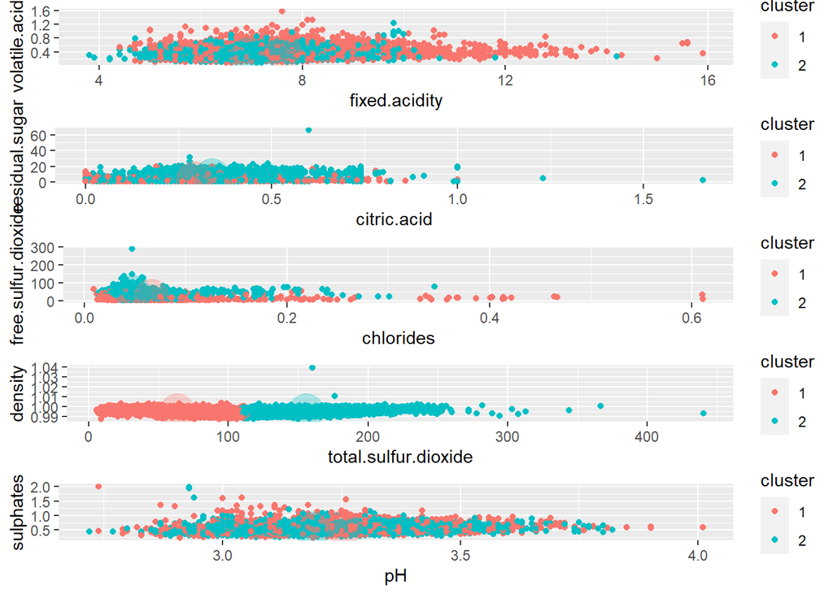

We see that several of the plots don’t do a good job of separating the red and the white wines. In fact, only one of the above plots – density vs. total sulfur dioxide – shows some distinction between the two kinds of wine. We need a different method.

**Using Principal Components Analysis (PCA) for clustering the two wines**

We run a PCA on the combined dataset as follows:

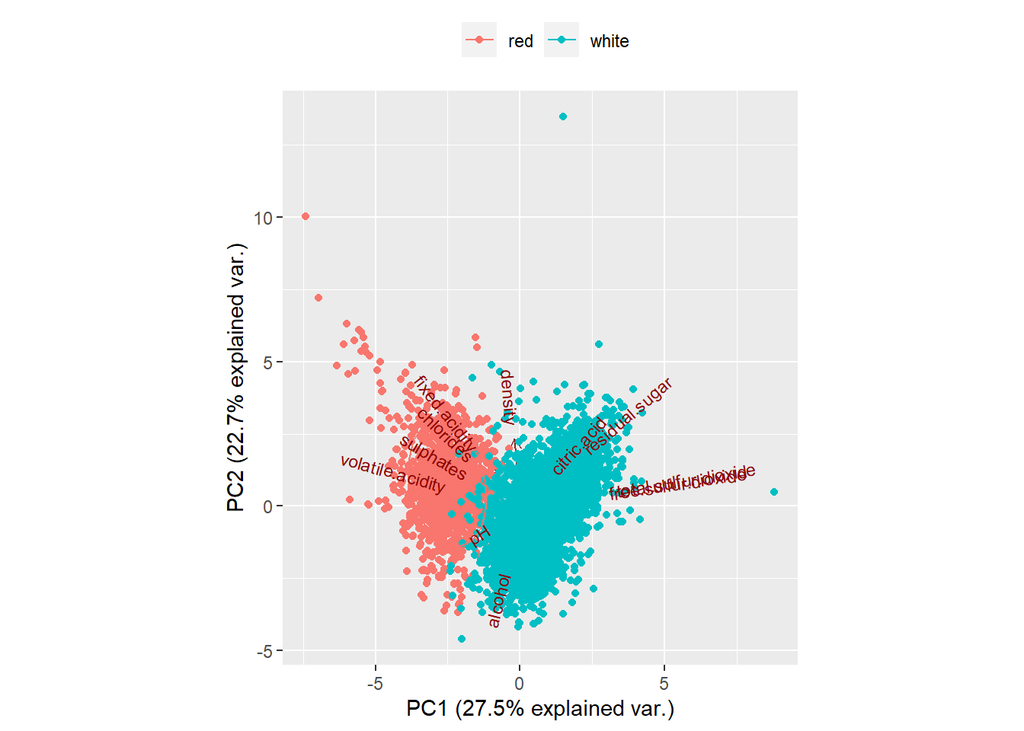

```r
source('https://raw.githubusercontent.com/vqv/ggbiplot/master/R/ggbiplot.r')

source('https://raw.githubusercontent.com/vqv/ggbiplot/master/R/ggscreeplot.r')

pca_total <- prcomp(total[,c(1:11)], scale. = TRUE, center = TRUE)

ggbiplot(pca_total, obs.scale = 1, var.scale = 1, groups = total$label, ellipse = TRUE) +
scale_color_discrete(name = '') +
theme(legend.direction = 'horizontal', legend.position = 'top')
```

PC1 vs. PC3:

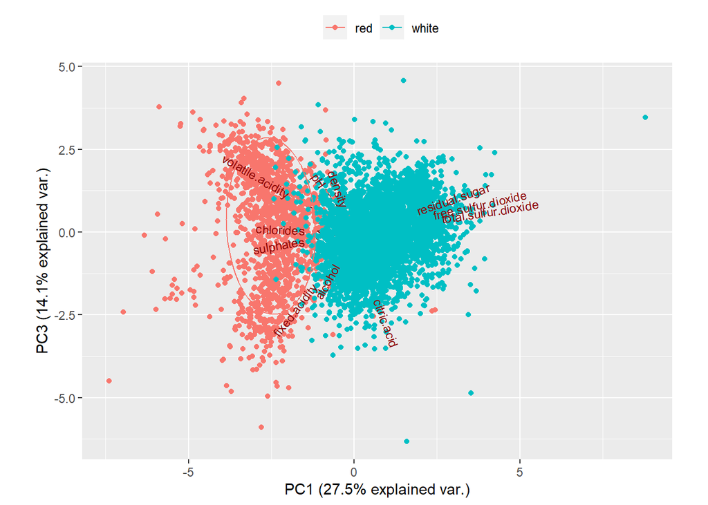

```r
ggbiplot(pca_total, obs.scale = 1, var.scale = 1, choices = c(1,3), groups = total$label, ellipse = TRUE) +
scale_color_discrete(name = '') +
theme(legend.direction = 'horizontal', legend.position = 'top')
```

PC1 vs. PC4:

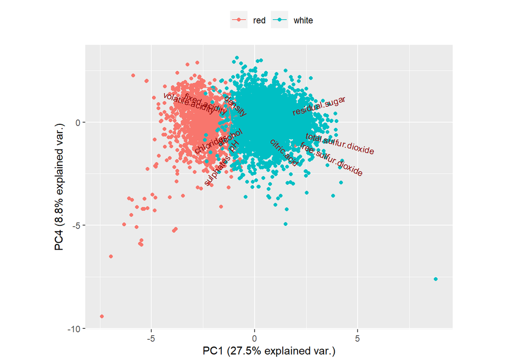

```r
ggbiplot(pca_total, obs.scale = 1, var.scale = 1, choices = c(1,4), groups = total$label, ellipse = TRUE) +
scale_color_discrete(name = '') +
theme(legend.direction = 'horizontal', legend.position = 'top')
```

As we can see, several of the Principal Components do a decent job of separating out the red wines and the white wines. This motivates us to analyze each type of wine separately for the rest of our project.

**Exploring Correlation Between Variables**

Correlated predictors are the bane of data analysis. Most of our classification methods require that the predictors in the model be as uncorrelated as possible. To that end, we use the strategy of removing one predictor variable from every pair of highly correlated variables in the dataset.

```r
corr_red <- cor(data_redwine[,c(1:11)])
corr_white <- cor(data_whitewine[, c(1:11)])
```

Correlation graphs/Heat-maps of the predictors for the Red wine dataset:

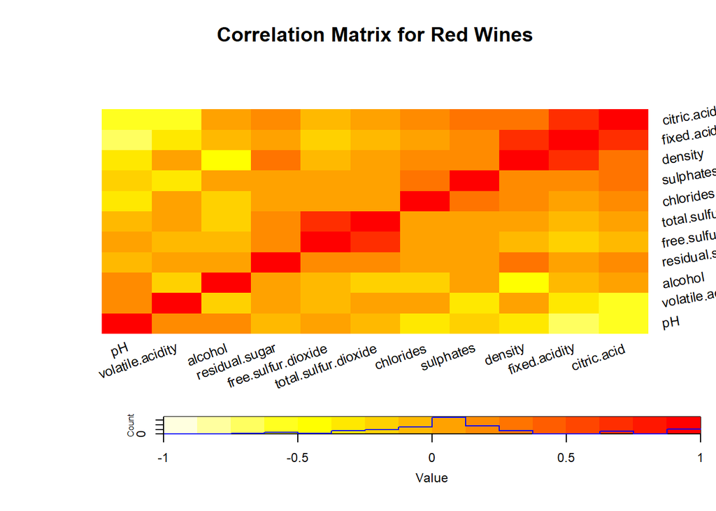

```r
library('gplots')
library('PerformanceAnalytics')
red_map <- heatmap.2(x = corr_red, col = rev(heat.colors(16)), symm = TRUE, dendrogram = 'none',
trace = 'none', main = "Correlation Matrix for Red Wines", key = TRUE,
 lmat=rbind( c(0, 3), c(2,1), c(0,4) ), lhei=c(1.5,4,1.5), lwid = c(0.5,3), srtRow = 10, srtCol = 20, symkey = TRUE, key.title = NA,
 tracecol = 'blue')
```

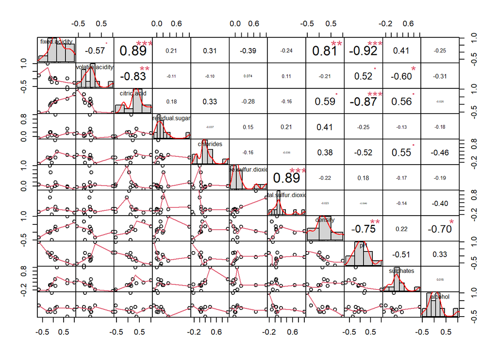

```r
chart.Correlation(corr_red, histogram = TRUE, pch = 1)
```

And for White wines:

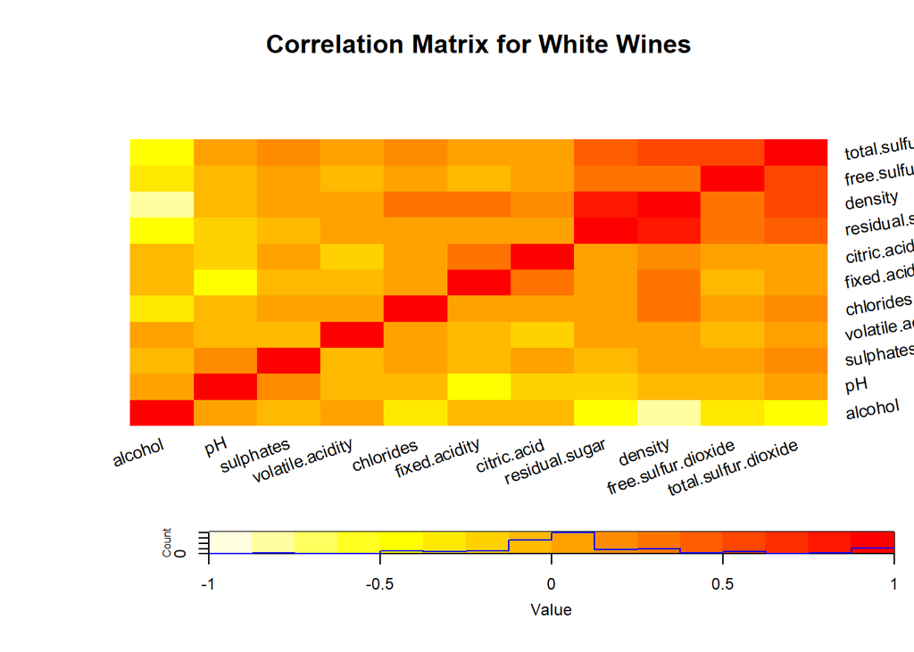

```r
white_map <- heatmap.2(x = corr_white, col = rev(heat.colors(16)), symm = TRUE, dendrogram = 'none',
trace = 'none', main = "Correlation Matrix for White Wines", key = TRUE,
 lmat=rbind( c(0, 3), c(2,1), c(0,4) ), lhei=c(1.5,4,1.5), lwid = c(0.5,3), srtRow = 10, srtCol = 20, symkey = TRUE, key.title = NA,
 tracecol = 'blue')
```

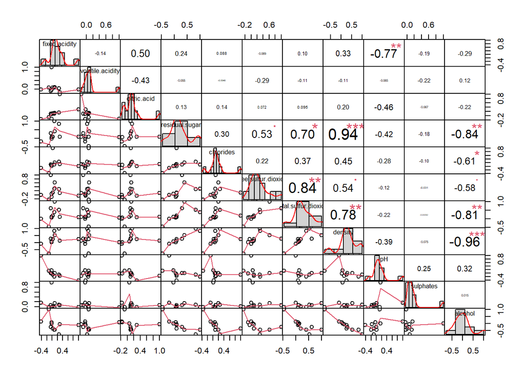

```r
chart.Correlation(corr_white, histogram = TRUE, pch = 1)
```

Some predictors are highly correlated in both datasets (>50%). Moreover, some of them are not the same pairs across both datasets. We use the strategy described above and remove the correlated variables that have a single red asterisk (*) or more in the correlation charts above.

This leads us to a filtered set of less correlated predictors to use for the rest of our analyses:

```r
# Retained variables for red
# citric.acid + residual.sugar + chlorides + free.sulfur.dioxide + sulphates + alcohol

vars_red <- c("citric.acid", "residual.sugar", "chlorides", "free.sulfur.dioxide", "sulphates", "alcohol", "quality")
data_redwine_reduced <- data_redwine[vars_red]

# Retained variables for white
# fixed.acidity + volatile.acidity + citric.acid + residual.sugar + chlorides + free.sulfur.dioxide + sulphates

vars_white <- c("fixed.acidity", "volatile.acidity", "citric.acid", "residual.sugar", "chlorides", "free.sulfur.dioxide", "sulphates", "quality")
data_whitewine_reduced <- data_whitewine[vars_white]
```

**The new correlation heatmaps**

First let’s create a correlation matrix

```r
corr_red_new <- cor(data_redwine_reduced)
corr_white_new <- cor(data_whitewine_reduced)
```

The new correlation heat map for red wines:

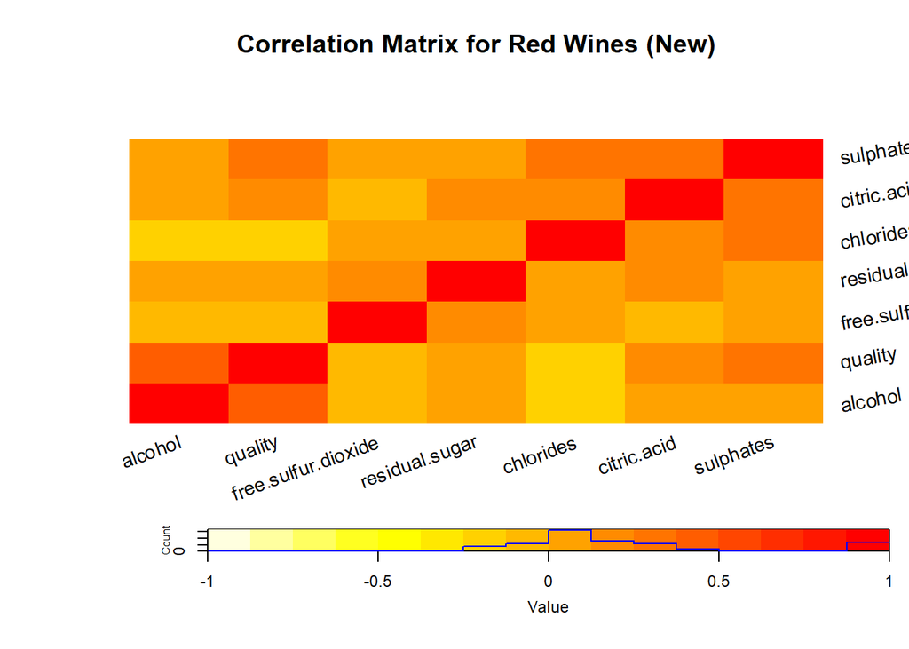

```r
red_map_new <- heatmap.2(x = corr_red_new, col = rev(heat.colors(16)), symm = TRUE, dendrogram = 'none',
trace = 'none', main = "Correlation Matrix for Red Wines (New)", key = TRUE,
 lmat=rbind( c(0, 3), c(2,1), c(0,4) ), lhei=c(1.5,4,1.5), lwid = c(0.5,3), srtRow = 10, srtCol = 20, symkey = TRUE, key.title = NA,
 tracecol = 'blue')
```

Similarly for white wines:

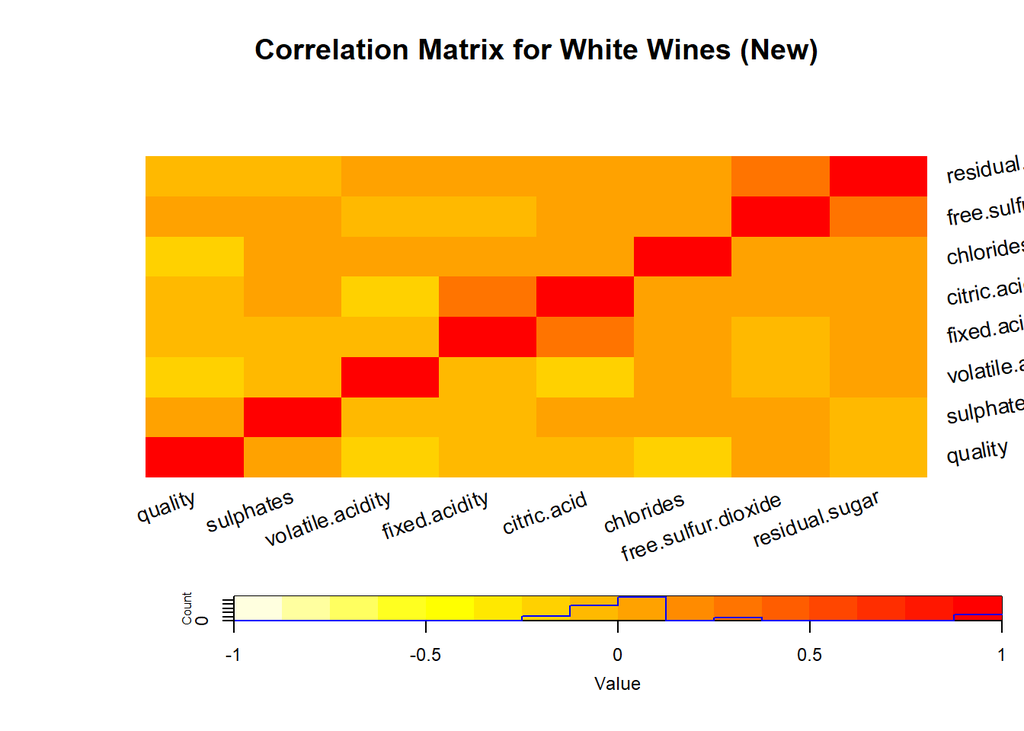

```r
white_map_new <- heatmap.2(x = corr_white_new, col = rev(heat.colors(16)), symm = TRUE, dendrogram = 'none',
trace = 'none', main = "Correlation Matrix for White Wines (New)", key = TRUE,
 lmat=rbind( c(0, 3), c(2,1), c(0,4) ), lhei=c(1.5,4,1.5), lwid = c(0.5,3), srtRow = 10, srtCol = 20, symkey = TRUE, key.title = NA,
 tracecol = 'blue')
```

### Building Predictors

**Assign Labels**

```r
# assign labels for red wine (full dataset)
data_red_wine_labelled <- mutate(data_redwine,
                                 label = case_when(
                                   quality > 6 ~ "good",
                                   quality <= 6 ~ "bad"
                                 ))

# assign labels for white wine (full dataset)
data_white_wine_labelled <- mutate(data_whitewine,
                                   label = case_when(
                                     quality > 6 ~ "good",
                                     quality <= 6 ~ "bad"
                                   ))


# assign labels for red wine (reduced dataset)
data_redwine_reduced_labelled <- mutate(data_redwine_reduced,
                                        label = case_when(
                                          quality > 6 ~ "good",
                                          quality <= 6 ~ "bad"
                                        ))

# assign labels for white wine (reduced dataset)
data_whitewine_reduced_labelled <- mutate(data_whitewine_reduced,
                                          label = case_when(
                                            quality > 6 ~ "good",
                                            quality <= 6 ~ "bad"
                                          ))


data_red_wine_labelled$label_binary <- as.numeric((data_red_wine_labelled$quality >6 ))
data_white_wine_labelled$label_binary <- as.numeric((data_white_wine_labelled$quality >6 ))

data_redwine_reduced_labelled$label_binary <- as.numeric((data_redwine_reduced_labelled$quality  >6 ))
data_whitewine_reduced_labelled$label_binary <- as.numeric((data_whitewine_reduced_labelled$quality >6 ))
```

**Data Partition** To compare the classifiers fairly, we will use the same partitioned training (80%) and testing (20%) data for all classifiers.

```r
# Partition red wine full dataset
set.seed(100000)
indxTrain_red_full <- createDataPartition(y = data_red_wine_labelled$label ,p = 0.8,list = FALSE)
traindata_red_full <- data_red_wine_labelled[indxTrain_red_full, !(names(data_red_wine_labelled) %in% c('quality'))]
testdata_red_full <- data_red_wine_labelled[-indxTrain_red_full, !(names(data_red_wine_labelled) %in% c('quality'))]

# Partition white wine full dataset
set.seed(100000)
indxTrain_white_full <- createDataPartition(y = data_white_wine_labelled$label ,p = 0.8,list = FALSE)
traindata_white_full <- data_white_wine_labelled[indxTrain_white_full, !(names(data_white_wine_labelled) %in% c('quality'))]
testdata_white_full <- data_white_wine_labelled[-indxTrain_white_full, !(names(data_white_wine_labelled) %in% c('quality'))]


# Partition red wine reduced dataset
set.seed(100000)
indxTrain_red_reduced <- createDataPartition(y = data_redwine_reduced_labelled$label ,p = 0.8,list = FALSE)
traindata_red_reduced <- data_redwine_reduced_labelled[indxTrain_red_reduced, !(names(data_redwine_reduced_labelled) %in% c('quality'))]
testdata_red_reduced <- data_redwine_reduced_labelled[-indxTrain_red_reduced, !(names(data_redwine_reduced_labelled) %in% c('quality'))]


# Partition white wine reduced dataset
set.seed(100000)
indxTrain_white_reduced <- createDataPartition(y = data_whitewine_reduced_labelled$label ,p = 0.8,list = FALSE) # uses random sampling
traindata_white_reduced <- data_whitewine_reduced_labelled[indxTrain_white_reduced, !(names(data_whitewine_reduced_labelled) %in% c('quality'))]
testdata_white_reduced <- data_whitewine_reduced_labelled[-indxTrain_white_reduced, !(names(data_whitewine_reduced_labelled) %in% c('quality'))]
```

**Naive Bayes**

**White Wine (Reduced Dataset)**

```r
### White Wine NB Analysis

nb_model_white_reduced <- naiveBayes(as.factor(label) ~ . - label_binary , traindata_white_reduced, laplace=.01)

nb_prediction_white_reduced <- predict(nb_model_white_reduced,
                                       # remove column "label" and "label_binary"
                                       testdata_white_full[,!(names(data_whitewine_reduced_labelled) %in% c('label', 'label_binary'))],
                                       type='raw')
nb_score_white_reduced <- nb_prediction_white_reduced[, c("good")]

actual_class_white_reduced <- testdata_white_reduced$label == 'good'
nb_pred_white_reduced <- prediction(nb_score_white_reduced, actual_class_white_reduced)
nb_perf_white_reduced <- performance(nb_pred_white_reduced, "tpr", "fpr")
```

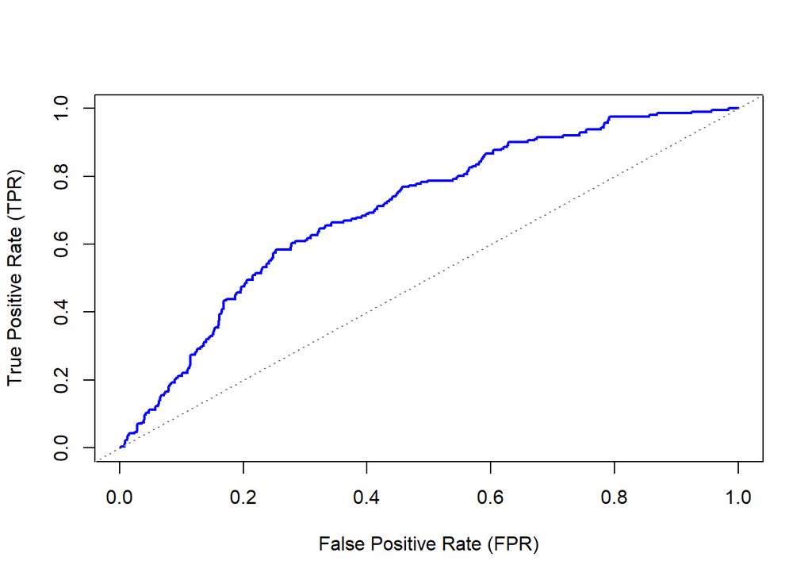

```r
plot(nb_perf_white_reduced, col="blue", lwd=2, xlab="False Positive Rate (FPR)", ylab="True Positive Rate (TPR)")
abline(a=0, b=1, col="gray50", lty=3)
```

```r
nb_auc_white_reduced <- performance(nb_pred_white_reduced, "auc")
nb_auc_white_reduced <- unlist(slot(nb_auc_white_reduced, "y.values"))
nb_auc_white_reduced
```

```
## [1] 0.7038818
```

**Red Wine (Reduced Dataset)**

```r
nb_model_red_reduced <- naiveBayes(as.factor(label) ~ . - label_binary, traindata_red_reduced, laplace=.01)

nb_prediction_red_reduced <- predict(nb_model_red_reduced,
                                     # remove column "label"
                                     testdata_red_full[,!(names(data_redwine_reduced_labelled) %in% c('label','label_binary'))],
                                     type='raw')

nb_score_red_reduced <- nb_prediction_red_reduced[, c("good")]

actual_class_red_reduced <- testdata_red_reduced$label == 'good'
nb_pred_red_reduced <- prediction(nb_score_red_reduced, actual_class_red_reduced)
nb_perf_red_reduced <- performance(nb_pred_red_reduced, "tpr", "fpr")
```

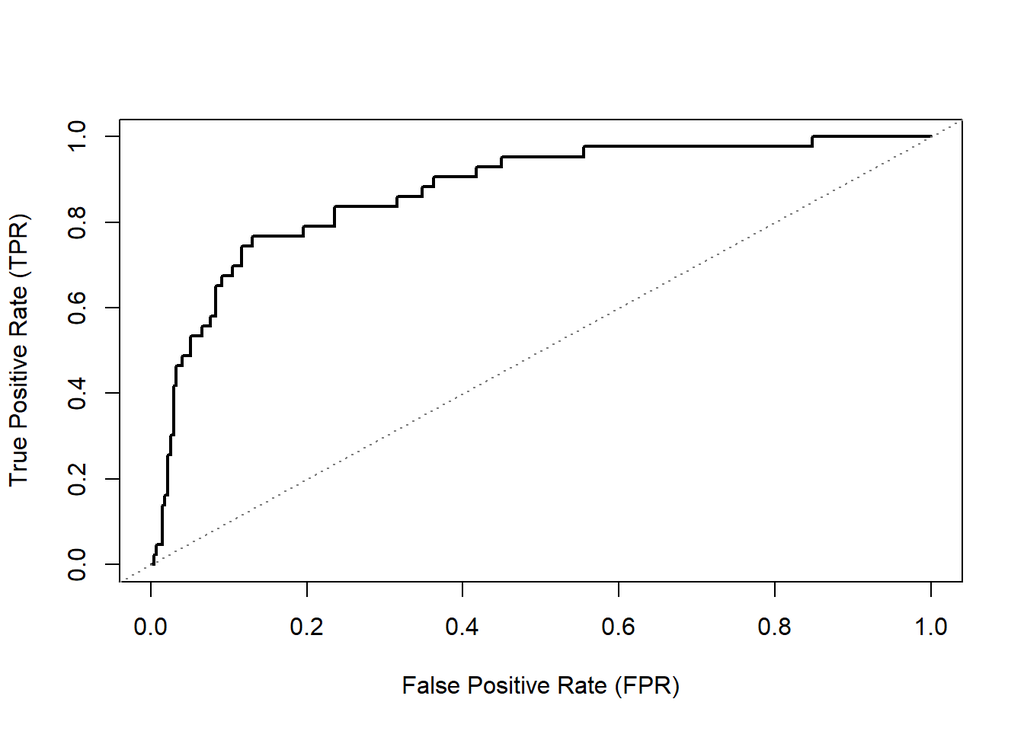

```r
plot(nb_perf_red_reduced, lwd=2, xlab="False Positive Rate (FPR)", ylab="True Positive Rate (TPR)")
abline(a=0, b=1, col="gray50", lty=3)
```

```r
nb_auc_red_reduced <- performance(nb_pred_red_reduced, "auc")
nb_auc_red_reduced <- unlist(slot(nb_auc_red_reduced, "y.values"))
nb_auc_red_reduced
```

```
## [1] 0.8724301
```

**Side-by-side Plot**

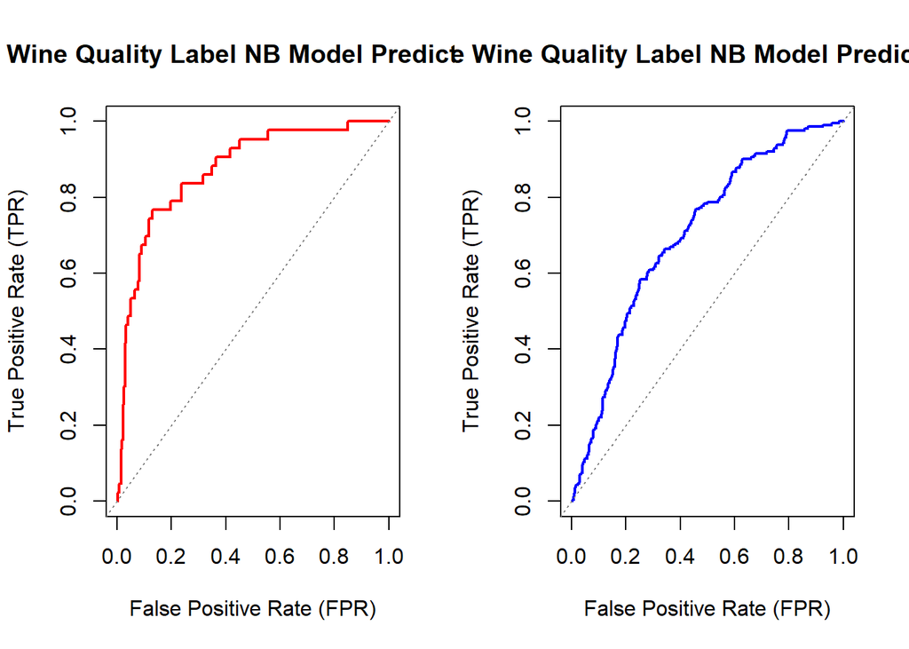

```r
par(mfrow=c(1,2))
plot(nb_perf_red_reduced, col="red", lwd=2, main="Red Wine Quality Label NB Model Prediction Perf", xlab="False Positive Rate (FPR)", ylab="True Positive Rate (TPR)")
abline(a=0, b=1, col="gray50", lty=3)
plot(nb_perf_white_reduced, col="blue", lwd=2, main="White Wine Quality Label NB Model Prediction Perf", xlab="False Positive Rate (FPR)", ylab="True Positive Rate (TPR)")
abline(a=0, b=1, col="gray50", lty=3)
```

**Multiple lines in single plot**

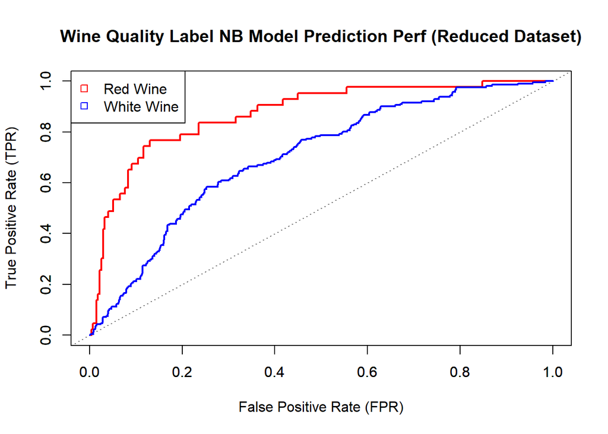

```r
par(mfrow=c(1,1))
plot(nb_perf_red_reduced, col="red", lwd=2, main="Wine Quality Label NB Model Prediction Perf (Reduced Dataset)", xlab="False Positive Rate (FPR)", ylab="True Positive Rate (TPR)")
abline(a=0, b=1, col="gray50", lty=3)

# par(new = TRUE)  # We draw on top of the existing plot.
# plot(perf, col = "red", lwd=2, main="", xlab="", ylab="")

par(new = TRUE)  # We draw on top of the existing plot.
plot(nb_perf_white_reduced, col = "blue", lwd=2, main="", xlab="", ylab="")

legend("topleft",
       legend = c("Red Wine", "White Wine"),
       col = c("red", "blue"),
       pch = c(0, 0, 0))
```

**White Wine**

```r
### White Wine NB Analysis

nb_model_white <- naiveBayes(as.factor(label) ~ . - label_binary , traindata_white_full, laplace=.01)

nb_prediction_white <- predict(nb_model_white,
                               # remove column "label"
                               testdata_white_full[,!(names(data_white_wine_labelled) %in% c('label', 'label_binary'))],
                               type='raw')

nb_score_white <- nb_prediction_white[, c("good")]

actual_class_white <- testdata_white_full$label == 'good'
nb_pred_white <- prediction(nb_score_white, actual_class_white)
nb_perf_white <- performance(nb_pred_white, "tpr", "fpr")
```

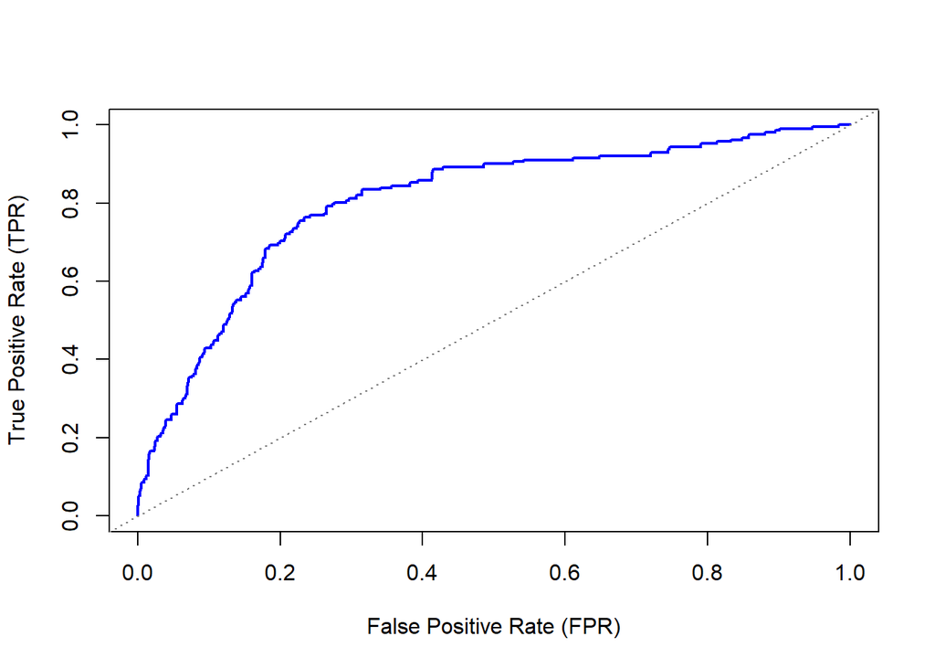

```r
plot(nb_perf_white, col="blue", lwd=2, xlab="False Positive Rate (FPR)", ylab="True Positive Rate (TPR)")
abline(a=0, b=1, col="gray50", lty=3)
```

```r
nb_auc_white <- performance(nb_pred_white, "auc")
nb_auc_white <- unlist(slot(nb_auc_white, "y.values"))
nb_auc_white
```

```
## [1] 0.8049925
```

**Red Wine**

```r
nb_model_red <- naiveBayes(as.factor(label) ~ . - label_binary, traindata_red_full, laplace=.01)

nb_prediction_red <- predict(nb_model_red,
                             # remove column "label"
                             testdata_red_full[,!(names(data_red_wine_labelled) %in% c('label','label_binary'))],
                             type='raw')

nb_score_red <- nb_prediction_red[, c("good")]

actual_class_red <- testdata_red_full$label == 'good'
nb_pred_red <- prediction(nb_score_red, actual_class_red)
nb_perf_red <- performance(nb_pred_red, "tpr", "fpr")
```

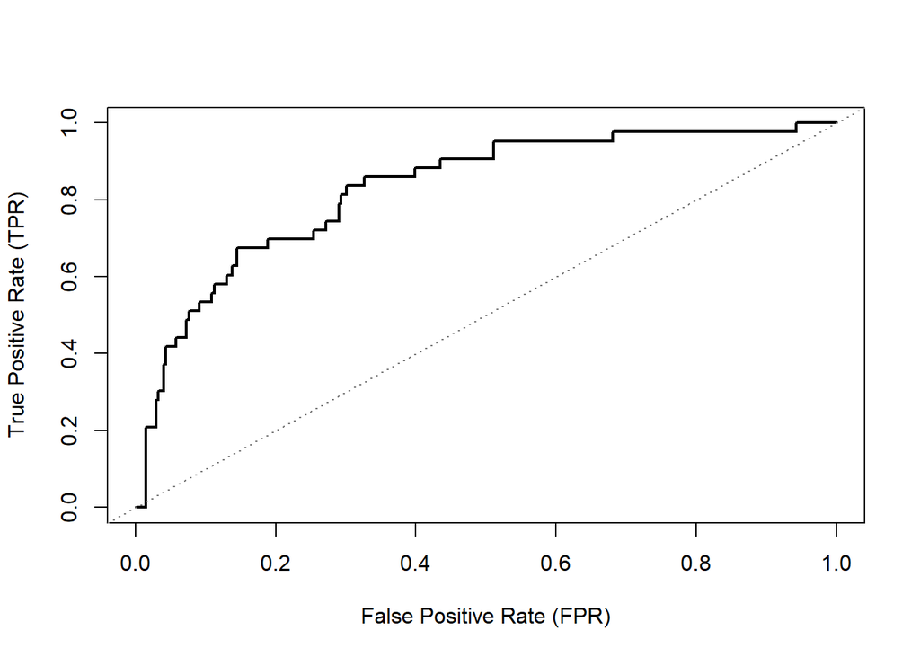

```r
plot(nb_perf_red, lwd=2, xlab="False Positive Rate (FPR)", ylab="True Positive Rate (TPR)")
abline(a=0, b=1, col="gray50", lty=3)
```

```r
nb_auc_red <- performance(nb_pred_red, "auc")
nb_auc_red <- unlist(slot(nb_auc_red, "y.values"))
nb_auc_red
```

```
## [1] 0.8303
```

**Side-by-side Plot**

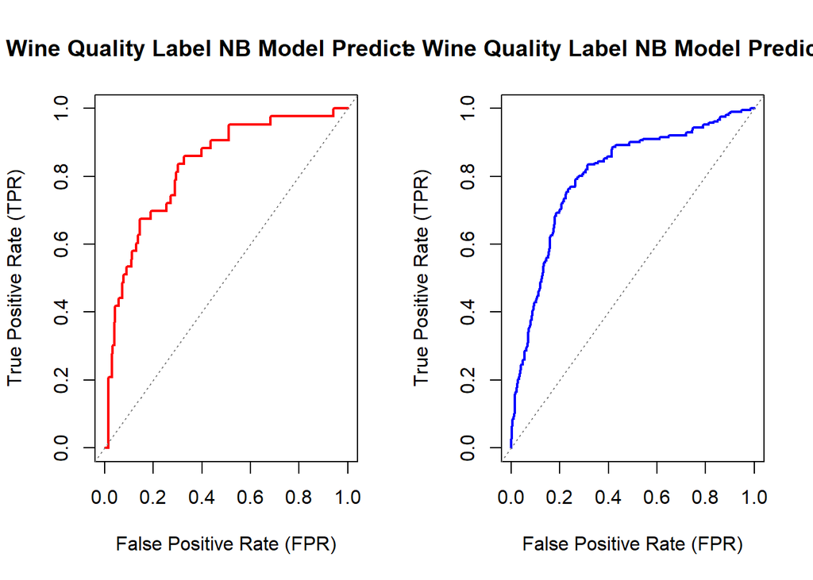

```r
par(mfrow=c(1,2))
plot(nb_perf_red, col="red", lwd=2, main="Red Wine Quality Label NB Model Prediction Perf", xlab="False Positive Rate (FPR)", ylab="True Positive Rate (TPR)")
abline(a=0, b=1, col="gray50", lty=3)
plot(nb_perf_white, col="blue", lwd=2, main="White Wine Quality Label NB Model Prediction Perf", xlab="False Positive Rate (FPR)", ylab="True Positive Rate (TPR)")
abline(a=0, b=1, col="gray50", lty=3)
```

**Multiple lines in single plot**

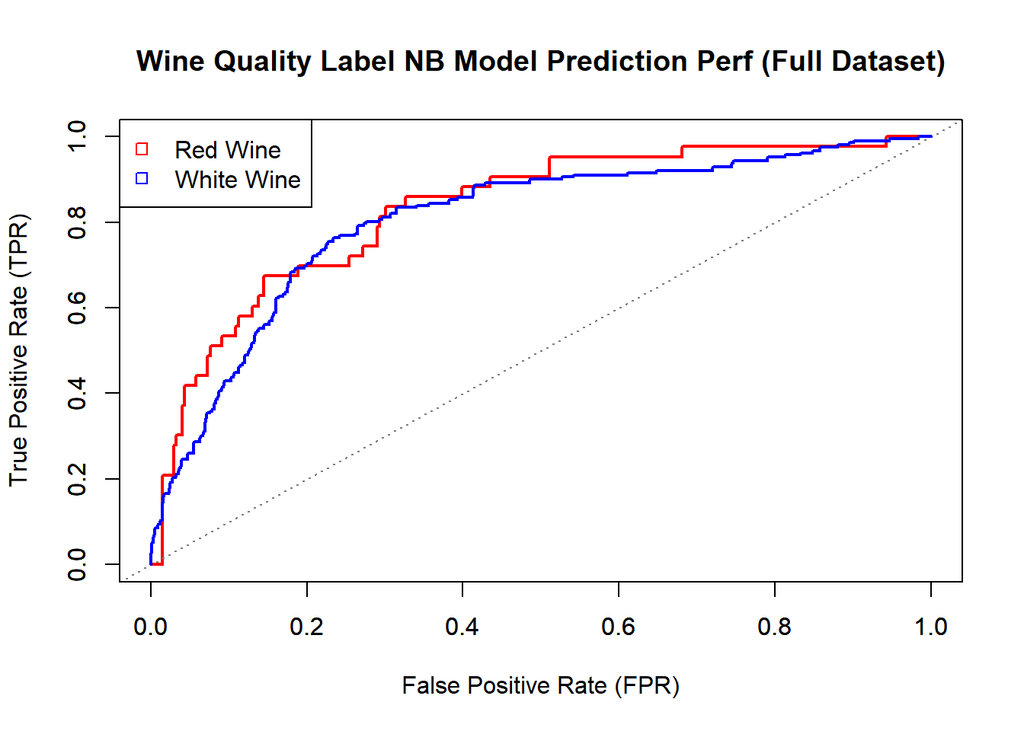

```r
par(mfrow=c(1,1))
plot(nb_perf_red, col="red", lwd=2, main="Wine Quality Label NB Model Prediction Perf (Full Dataset)", xlab="False Positive Rate (FPR)", ylab="True Positive Rate (TPR)")
abline(a=0, b=1, col="gray50", lty=3)

# par(new = TRUE)  # We draw on top of the existing plot.
# plot(perf, col = "red", lwd=2, main="", xlab="", ylab="")

par(new = TRUE)  # We draw on top of the existing plot.
plot(nb_perf_white, col = "blue", lwd=2, main="", xlab="", ylab="")

legend("topleft",
       legend = c("Red Wine", "White Wine"),
       col = c("red", "blue"),
       pch = c(0, 0, 0))
```

**AUCs (Full Dataset)**

```r
print(paste0("AUC of NB Model (Red Wine Full Dataset):", nb_auc_red))
```

```
## [1] "AUC of NB Model (Red Wine Full Dataset):0.830299966295919"
```

```r
print(paste0("AUC of NB Model (White Wine Full Dataset):", nb_auc_white))
```

```
## [1] "AUC of NB Model (White Wine Full Dataset):0.804992497109541"
```

**Logistic Regression**

Aim: To predict whether the wine is above median quality or otherwise - Hence the response variable would be the binary variable whether the wine is “good” or “bad”

How we chose the predictors: - Full model with all the predictors - Violates the assumption that variables have to be independent from one another - Good for comparison - Remove correlated variables for a reduced model as per EDA - Fulfills all the assumptions

Split the data into training data and testing data into 80/20 percent of the dataset respectively. - Model is created using training data - ROC curve and AUC is derived using testing data - Done to ensure overfitting does not happen

**Red Wine**

**Full Model**

```r
red_lr_train <- glm(formula = label_binary ~
                      fixed.acidity + volatile.acidity + citric.acid
                    + residual.sugar + chlorides + free.sulfur.dioxide
                    + total.sulfur.dioxide + density + pH
                    + sulphates + alcohol, data = traindata_red_full,
                    family = binomial(link="logit"))

summary(red_lr_train)
```

```
##
## Call:
## glm(formula = label_binary ~ fixed.acidity + volatile.acidity +
##     citric.acid + residual.sugar + chlorides + free.sulfur.dioxide +
##     total.sulfur.dioxide + density + pH + sulphates + alcohol,
##     family = binomial(link = "logit"), data = traindata_red_full)
##
## Deviance Residuals:
##     Min       1Q   Median       3Q      Max
## -3.0571  -0.4216  -0.2163  -0.1170   2.8312
##
## Coefficients:
##                        Estimate Std. Error z value Pr(>|z|)
## (Intercept)           2.939e+02  1.214e+02   2.422  0.01544 *
## fixed.acidity         2.644e-01  1.417e-01   1.866  0.06209 .
## volatile.acidity     -2.558e+00  8.966e-01  -2.853  0.00434 **
## citric.acid           6.942e-01  9.381e-01   0.740  0.45925
## residual.sugar        2.475e-01  7.944e-02   3.116  0.00184 **
## chlorides            -8.246e+00  3.434e+00  -2.401  0.01634 *
## free.sulfur.dioxide   1.566e-02  1.379e-02   1.136  0.25615
## total.sulfur.dioxide -1.869e-02  5.937e-03  -3.148  0.00164 **
## density              -3.059e+02  1.240e+02  -2.467  0.01364 *
## pH                   -7.443e-01  1.173e+00  -0.634  0.52580
## sulphates             3.790e+00  6.362e-01   5.958 2.55e-09 ***
## alcohol               7.438e-01  1.457e-01   5.105 3.31e-07 ***
## ---
## Signif. codes:  0 '***' 0.001 '**' 0.01 '*' 0.05 '.' 0.1 ' ' 1
##
## (Dispersion parameter for binomial family taken to be 1)
##
##     Null deviance: 1017.65  on 1279  degrees of freedom
## Residual deviance:  687.74  on 1268  degrees of freedom
## AIC: 711.74
##
## Number of Fisher Scoring iterations: 6
```

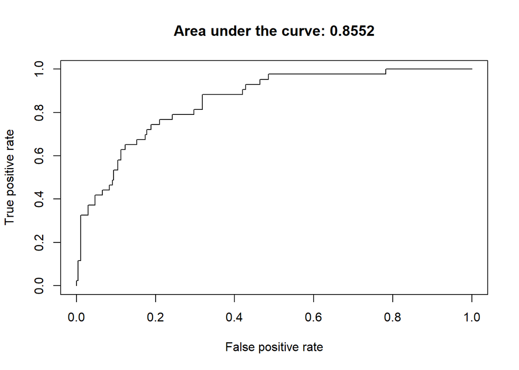

```r
pred = predict.glm(red_lr_train,testdata_red_full,  type="response")
predObj <- prediction(pred, testdata_red_full$label_binary)
rocObj = performance(predObj, measure="tpr", x.measure="fpr")
aucObj = performance(predObj, measure="auc")
plot(rocObj, main = paste("Area under the curve:",
                          round(aucObj@y.values[[1]] ,4)))
```

```r
lr_auc_red <- round(aucObj@y.values[[1]] ,4)
```

**Reduced Model**

```r
red_lr_train_reduced <- glm(formula = label_binary ~
                              citric.acid
                            + residual.sugar + chlorides + free.sulfur.dioxide
                            + sulphates + alcohol, data = traindata_red_reduced,
                            family = binomial(link="logit"))

summary(red_lr_train_reduced)
```

```
##
## Call:
## glm(formula = label_binary ~ citric.acid + residual.sugar + chlorides +
##     free.sulfur.dioxide + sulphates + alcohol, family = binomial(link = "logit"),
##     data = traindata_red_reduced)
##
## Deviance Residuals:
##     Min       1Q   Median       3Q      Max
## -2.6603  -0.4518  -0.2455  -0.1610   2.9311
##
## Coefficients:
##                       Estimate Std. Error z value Pr(>|z|)
## (Intercept)         -14.784556   1.249219 -11.835  < 2e-16 ***
## citric.acid           2.893960   0.528193   5.479 4.28e-08 ***
## residual.sugar        0.029863   0.069530   0.429  0.66756
## chlorides           -12.057117   3.775605  -3.193  0.00141 **
## free.sulfur.dioxide  -0.017101   0.009844  -1.737  0.08237 .
## sulphates             3.473044   0.576068   6.029 1.65e-09 ***
## alcohol               0.993624   0.093853  10.587  < 2e-16 ***
## ---
## Signif. codes:  0 '***' 0.001 '**' 0.01 '*' 0.05 '.' 0.1 ' ' 1
##
## (Dispersion parameter for binomial family taken to be 1)
##
##     Null deviance: 1017.7  on 1279  degrees of freedom
## Residual deviance:  732.2  on 1273  degrees of freedom
## AIC: 746.2
##
## Number of Fisher Scoring iterations: 6
```

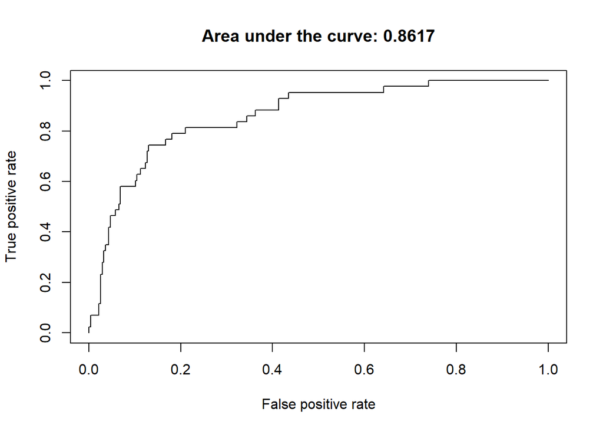

```r
pred = predict.glm(red_lr_train_reduced, testdata_red_reduced,  type="response")
predObj <- prediction(pred, testdata_red_reduced$label_binary)
rocObj = performance(predObj, measure="tpr", x.measure="fpr")
aucObj = performance(predObj, measure="auc")
plot(rocObj, main = paste("Area under the curve:",
                          round(aucObj@y.values[[1]] ,4)))
```

```r
lr_perf_red_reduced <- rocObj
lr_auc_red_reduced <- round(aucObj@y.values[[1]] ,4)
```

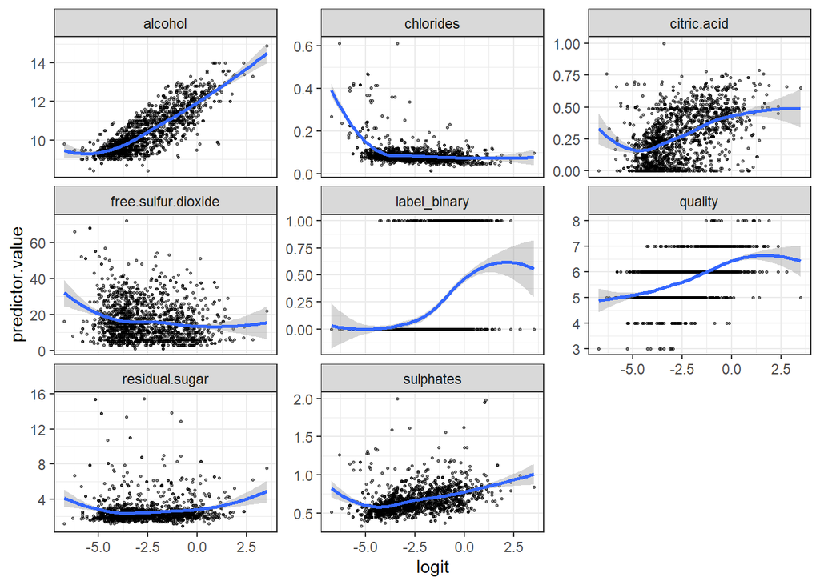

```r
# Select only numeric predictors
mydata <- data_redwine_reduced_labelled %>%
  dplyr::select_if(is.numeric)
predictors <- colnames(mydata)
probabilities <- predict(red_lr_train_reduced, newdata = data_redwine_reduced_labelled ,type = "response")
# Bind the logit and tidying the data for plot
mydata <- mydata %>%
  mutate(logit = log(probabilities/(1-probabilities))) %>%
  gather(key = "predictors", value = "predictor.value", -logit)

ggplot(mydata, aes(logit, predictor.value))+
  geom_point(size = 0.5, alpha = 0.5) +
  geom_smooth(method = "loess") +
  theme_bw() +
  facet_wrap(~predictors, scales = "free_y")
```

**White Wine**

**Full Model**

```r
white_lr_train <- glm(formula = label_binary ~
                        fixed.acidity + volatile.acidity + citric.acid
                      + residual.sugar + chlorides + free.sulfur.dioxide
                      + total.sulfur.dioxide + density + pH
                      + sulphates + alcohol, data = traindata_white_full,
                      family = binomial(link="logit"))

summary(white_lr_train)
```

```
##
## Call:
## glm(formula = label_binary ~ fixed.acidity + volatile.acidity +
##     citric.acid + residual.sugar + chlorides + free.sulfur.dioxide +
##     total.sulfur.dioxide + density + pH + sulphates + alcohol,
##     family = binomial(link = "logit"), data = traindata_white_full)
##
## Deviance Residuals:
##     Min       1Q   Median       3Q      Max
## -2.2477  -0.6742  -0.4220  -0.1834   2.7858
##
## Coefficients:
##                        Estimate Std. Error z value Pr(>|z|)
## (Intercept)           6.264e+02  1.044e+02   6.001 1.96e-09 ***
## fixed.acidity         5.926e-01  1.004e-01   5.902 3.60e-09 ***
## volatile.acidity     -3.749e+00  5.369e-01  -6.983 2.89e-12 ***
## citric.acid          -7.900e-01  4.441e-01  -1.779   0.0752 .
## residual.sugar        2.984e-01  3.951e-02   7.553 4.27e-14 ***
## chlorides            -1.087e+01  4.144e+00  -2.623   0.0087 **
## free.sulfur.dioxide   8.196e-03  3.465e-03   2.365   0.0180 *
## total.sulfur.dioxide -3.236e-04  1.681e-03  -0.192   0.8474
## density              -6.499e+02  1.058e+02  -6.143 8.12e-10 ***
## pH                    3.488e+00  4.747e-01   7.347 2.02e-13 ***
## sulphates             1.909e+00  3.857e-01   4.949 7.45e-07 ***
## alcohol               1.433e-01  1.263e-01   1.135   0.2565
## ---
## Signif. codes:  0 '***' 0.001 '**' 0.01 '*' 0.05 '.' 0.1 ' ' 1
##
## (Dispersion parameter for binomial family taken to be 1)
##
##     Null deviance: 4093.7  on 3918  degrees of freedom
## Residual deviance: 3348.4  on 3907  degrees of freedom
## AIC: 3372.4
##
## Number of Fisher Scoring iterations: 6
```

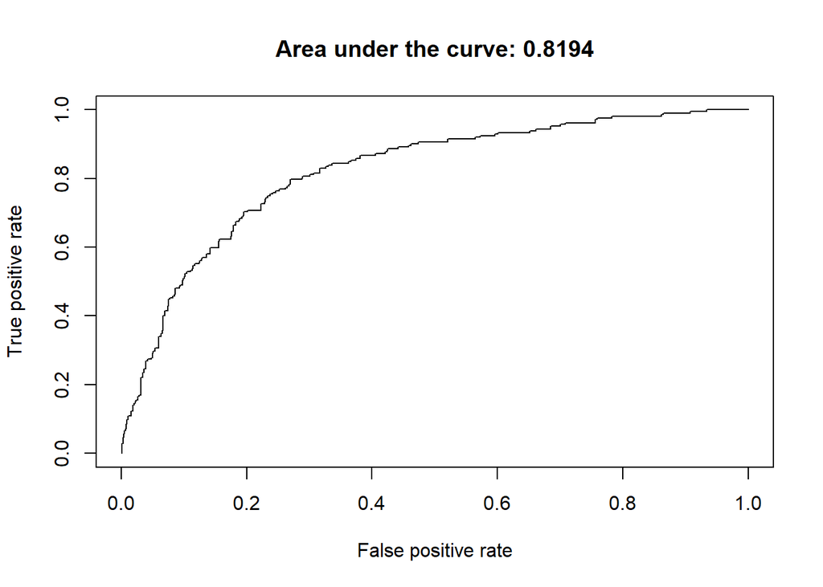

```r
pred = predict.glm(white_lr_train, testdata_white_full,  type="response")
predObj <- prediction(pred, testdata_white_full$label_binary)
rocObj = performance(predObj, measure="tpr", x.measure="fpr")
aucObj = performance(predObj, measure="auc")
plot(rocObj, main = paste("Area under the curve:",
                          round(aucObj@y.values[[1]] ,4)))
```

```r
lr_auc_white <- round(aucObj@y.values[[1]] ,4)
```

**Reduced Model**

```r
white_lr_train_reduced <- glm(formula = label_binary ~
                                fixed.acidity + volatile.acidity + citric.acid
                              + residual.sugar + chlorides + free.sulfur.dioxide
                              + sulphates, data = traindata_white_reduced,
                              family = binomial(link="logit"))

summary(white_lr_train_reduced)
```

```
##
## Call:
## glm(formula = label_binary ~ fixed.acidity + volatile.acidity +
##     citric.acid + residual.sugar + chlorides + free.sulfur.dioxide +
##     sulphates, family = binomial(link = "logit"), data = traindata_white_reduced)
##
## Deviance Residuals:
##     Min       1Q   Median       3Q      Max
## -1.4520  -0.7402  -0.5784  -0.2340   3.5343
##
## Coefficients:
##                       Estimate Std. Error z value Pr(>|z|)
## (Intercept)           2.048571   0.426369   4.805 1.55e-06 ***
## fixed.acidity        -0.129183   0.050037  -2.582 0.009830 **
## volatile.acidity     -1.652724   0.446909  -3.698 0.000217 ***
## citric.acid          -0.349132   0.383067  -0.911 0.362078
## residual.sugar       -0.027042   0.009325  -2.900 0.003732 **
## chlorides           -54.943570   4.393521 -12.506  < 2e-16 ***
## free.sulfur.dioxide   0.003434   0.002461   1.396 0.162836
## sulphates             0.909357   0.338748   2.684 0.007265 **
## ---
## Signif. codes:  0 '***' 0.001 '**' 0.01 '*' 0.05 '.' 0.1 ' ' 1
##
## (Dispersion parameter for binomial family taken to be 1)
##
##     Null deviance: 4093.7  on 3918  degrees of freedom
## Residual deviance: 3789.0  on 3911  degrees of freedom
## AIC: 3805
##
## Number of Fisher Scoring iterations: 5
```

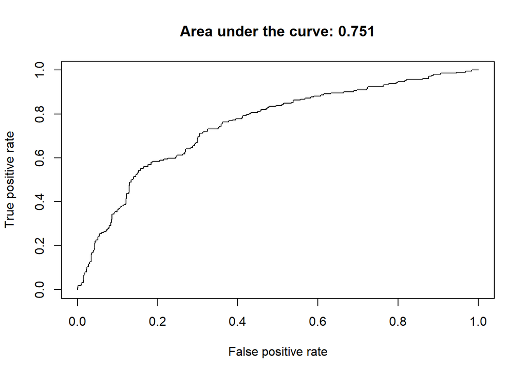

```r
pred = predict.glm(white_lr_train_reduced, testdata_white_reduced,  type="response")
predObj <- prediction(pred, testdata_white_reduced$label_binary)
rocObj = performance(predObj, measure="tpr", x.measure="fpr")
aucObj = performance(predObj, measure="auc")
plot(rocObj, main = paste("Area under the curve:",
                          round(aucObj@y.values[[1]] ,4)))
```

```r
lr_perf_white_reduced <- rocObj
lr_auc_white_reduced <- round(aucObj@y.values[[1]] ,4)
```

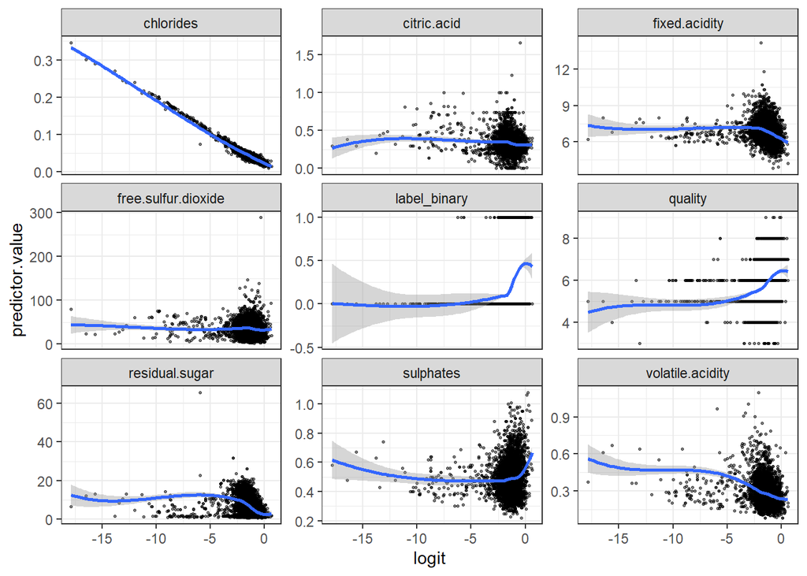

```r
# Select only numeric predictors
mydata <- data_whitewine_reduced_labelled %>%
  dplyr::select_if(is.numeric)
predictors <- colnames(mydata)
probabilities <- predict(white_lr_train_reduced, newdata = data_whitewine_reduced_labelled ,type = "response")
# Bind the logit and tidying the data for plot
mydata <- mydata %>%
  mutate(logit = log(probabilities/(1-probabilities))) %>%
  gather(key = "predictors", value = "predictor.value", -logit)

ggplot(mydata, aes(logit, predictor.value))+
  geom_point(size = 0.5, alpha = 0.5) +
  geom_smooth(method = "loess") +
  theme_bw() +
  facet_wrap(~predictors, scales = "free_y")
```

**Decision Trees**

```r
# Red wine (reduced dataset)
dt_fit_red_reduced  <- rpart(label ~ citric.acid
                             + residual.sugar + chlorides + free.sulfur.dioxide
                             + sulphates + alcohol, data=traindata_red_reduced,control=rpart.control(minsplit=128), method="class",
                             parms=list(split='information'))
summary(dt_fit_red_reduced)
```

```
## Call:
## rpart(formula = label ~ citric.acid + residual.sugar + chlorides +
##     free.sulfur.dioxide + sulphates + alcohol, data = traindata_red_reduced,
##     method = "class", parms = list(split = "information"), control = rpart.control(minsplit = 128))
##   n= 1280
##
##           CP nsplit rel error   xerror       xstd
## 1 0.03639847      0 1.0000000 1.000000 0.07046897
## 2 0.01000000      3 0.8908046 1.063218 0.07230007
##
## Variable importance
##             alcohol           sulphates           chlorides         citric.acid
##                  57                  21                  11                   6
##      residual.sugar free.sulfur.dioxide
##                   2                   2
##
## Node number 1: 1280 observations,    complexity param=0.03639847
##   predicted class=bad   expected loss=0.1359375  P(node) =1
##     class counts:  1106   174
##    probabilities: 0.864 0.136
##   left son=2 (739 obs) right son=3 (541 obs)
##   Primary splits:
##       alcohol             < 10.45    to the left,  improve=83.585570, (0 missing)
##       sulphates           < 0.685    to the left,  improve=47.384780, (0 missing)
##       citric.acid         < 0.315    to the left,  improve=46.525590, (0 missing)
##       chlorides           < 0.0675   to the right, improve=21.069190, (0 missing)
##       free.sulfur.dioxide < 13.5     to the right, improve= 7.970615, (0 missing)
##   Surrogate splits:
##       chlorides           < 0.0685   to the right, agree=0.662, adj=0.201, (0 split)
##       sulphates           < 0.675    to the left,  agree=0.636, adj=0.139, (0 split)
##       citric.acid         < 0.315    to the left,  agree=0.624, adj=0.111, (0 split)
##       residual.sugar      < 4.15     to the left,  agree=0.592, adj=0.035, (0 split)
##       free.sulfur.dioxide < 3.5      to the right, agree=0.586, adj=0.020, (0 split)
##
## Node number 2: 739 observations
##   predicted class=bad   expected loss=0.03247632  P(node) =0.5773438
##     class counts:   715    24
##    probabilities: 0.968 0.032
##
## Node number 3: 541 observations,    complexity param=0.03639847
```

[output cut: 30 more lines]

```
##       sulphates           < 0.795    to the left,  improve=0.2092203, (0 missing)
##   Surrogate splits:
##       chlorides      < 0.053    to the right, agree=0.685, adj=0.138, (0 split)
##       residual.sugar < 6.15     to the left,  agree=0.669, adj=0.092, (0 split)
##       citric.acid    < 0.015    to the right, agree=0.663, adj=0.077, (0 split)
##
## Node number 14: 113 observations
##   predicted class=bad   expected loss=0.3628319  P(node) =0.08828125
##     class counts:    72    41
##    probabilities: 0.637 0.363
##
## Node number 15: 65 observations
##   predicted class=good  expected loss=0.3538462  P(node) =0.05078125
##     class counts:    23    42
##    probabilities: 0.354 0.646
```

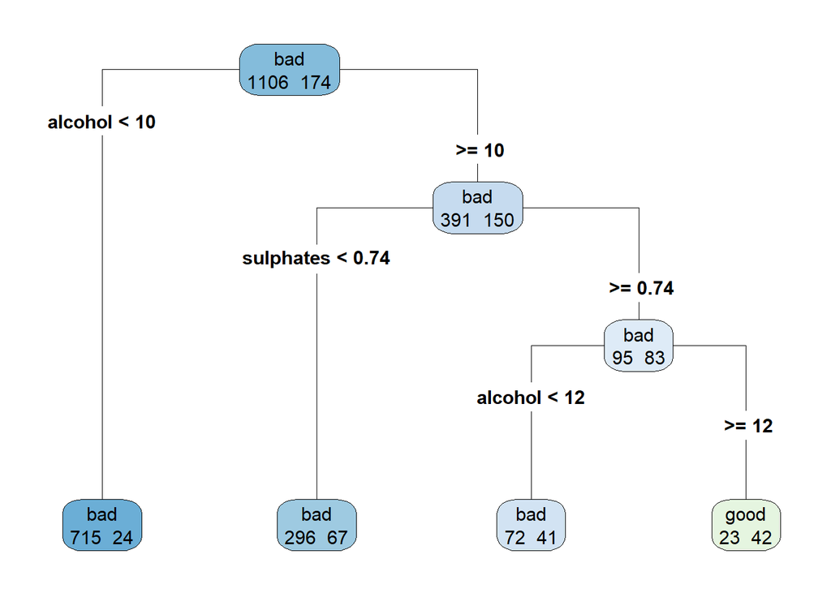

```r
rpart.plot(dt_fit_red_reduced, type=4, extra=1)
```

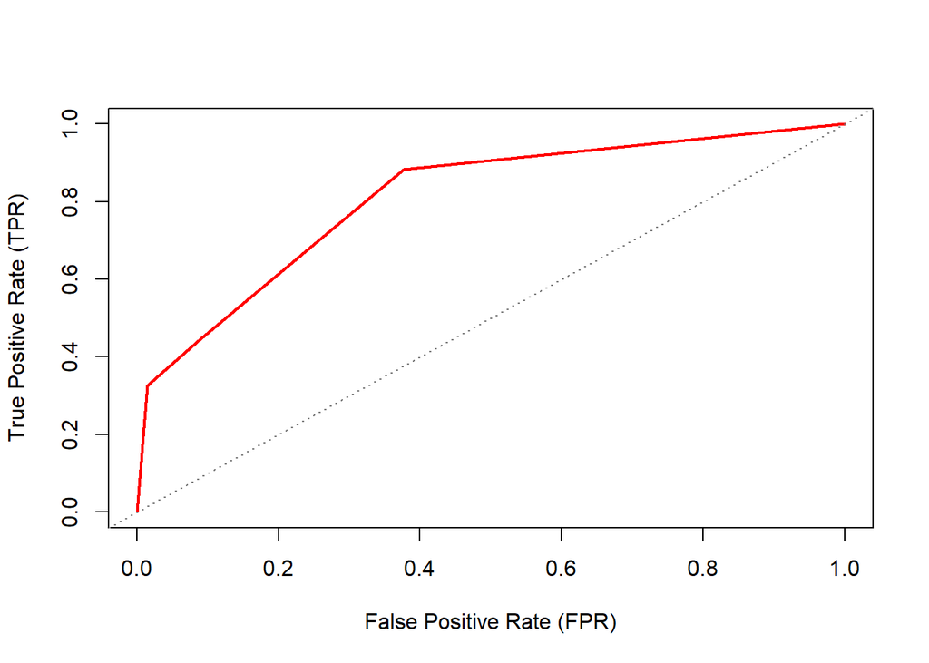

```r
dt_prediction_red_reduced <- predict(dt_fit_red_reduced,
                                     testdata_red_reduced[, !(names(data_redwine_reduced_labelled) %in% c('label', 'label_binary'))],
                                     type='prob')

dt_pred_red_reduced <- prediction(dt_prediction_red_reduced[, 2], testdata_red_reduced$label)

dt_perf_red_reduced <- performance(dt_pred_red_reduced, "tpr", "fpr")


plot(dt_perf_red_reduced, col="red", lwd=2, xlab="False Positive Rate (FPR)", ylab="True Positive Rate (TPR)")
abline(a=0, b=1, col="gray50", lty=3)
```

```r
dt_auc_red_reduced <- performance(dt_pred_red_reduced, "auc")
dt_auc_red_reduced <- unlist(slot(dt_auc_red_reduced,"y.values"))
dt_auc_red_reduced
```

```
## [1] 0.8092349
```

```r
# White wine (reduced dataset)
dt_fit_white_reduced <- rpart(label_binary ~ . - label,
                              data=traindata_white_reduced,
                              control=rpart.control(minsplit=390),
                              method="class", parms=list(split='information'))
summary(dt_fit_white_reduced)
```

```
## Call:
## rpart(formula = label_binary ~ . - label, data = traindata_white_reduced,
##     method = "class", parms = list(split = "information"), control = rpart.control(minsplit = 390))
##   n= 3919
##
##            CP nsplit rel error xerror xstd
## 1 0.008726415      0         1      0    0
##
## Node number 1: 3919 observations
##   predicted class=0  expected loss=0.2163817  P(node) =1
##     class counts:  3071   848
##    probabilities: 0.784 0.216
```

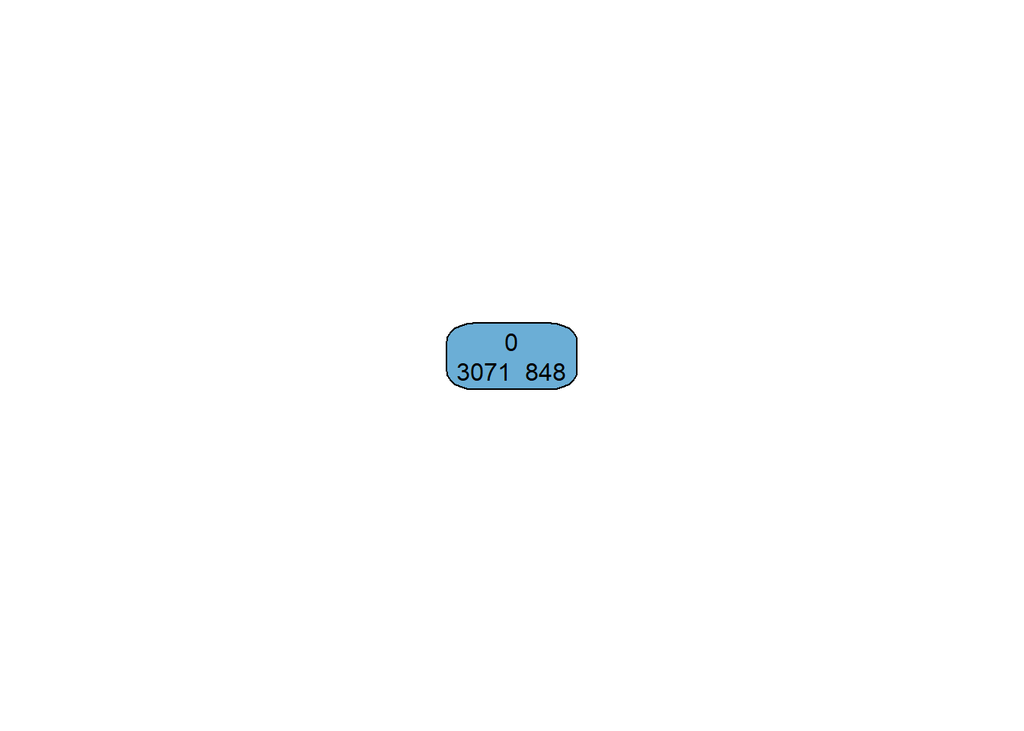

```r
rpart.plot(dt_fit_white_reduced , type=4, extra=1)
```

```r
# dt_pred_white_reduced <- prediction(predict(dt_fit_white_reduced, type = "prob")[, 2], data_whitewine_reduced_labelled$label)
# dt_perf_white_reduced <- performance(dt_pred_white_reduced, "tpr", "fpr")
#
#
# plot(dt_perf_white_reduced, col="blue", lwd=2, xlab="False Positive Rate (FPR)", ylab="True Positive Rate (TPR)")
# abline(a=0, b=1, col="gray50", lty=3)
```

```r
# dt_auc_white_reduced <- performance(dt_pred_white_reduced, "auc")
# dt_auc_white_reduced <- unlist(slot(dt_auc_white_reduced,"y.values"))
# dt_auc_white_reduced
```

```r
# Red wine (full dataset)
dt_fit_red_full  <- rpart(label ~ fixed.acidity + volatile.acidity + citric.acid + residual.sugar + chlorides + free.sulfur.dioxide + total.sulfur.dioxide + density + pH + sulphates + alcohol, data=traindata_red_full,control=rpart.control(minsplit=128), method="class",
                          parms=list(split='information'))
summary(dt_fit_red_full)
```

```
## Call:
## rpart(formula = label ~ fixed.acidity + volatile.acidity + citric.acid +
##     residual.sugar + chlorides + free.sulfur.dioxide + total.sulfur.dioxide +
##     density + pH + sulphates + alcohol, data = traindata_red_full,
##     method = "class", parms = list(split = "information"), control = rpart.control(minsplit = 128))
##   n= 1280
##
##           CP nsplit rel error    xerror       xstd
## 1 0.03256705      0 1.0000000 1.0000000 0.07046897
## 2 0.01000000      3 0.9022989 0.9655172 0.06943090
##
## Variable importance
##              alcohol     volatile.acidity              density
##                   36                   15                   13
##            sulphates          citric.acid            chlorides
##                   10                   10                    8
##        fixed.acidity                   pH total.sulfur.dioxide
##                    3                    3                    1
##  free.sulfur.dioxide
##                    1
##
## Node number 1: 1280 observations,    complexity param=0.03256705
##   predicted class=bad   expected loss=0.1359375  P(node) =1
##     class counts:  1106   174
##    probabilities: 0.864 0.136
##   left son=2 (739 obs) right son=3 (541 obs)
##   Primary splits:
##       alcohol          < 10.45    to the left,  improve=83.58557, (0 missing)
##       volatile.acidity < 0.385    to the right, improve=50.87817, (0 missing)
##       sulphates        < 0.685    to the left,  improve=47.38478, (0 missing)
##       citric.acid      < 0.315    to the left,  improve=46.52559, (0 missing)
##       density          < 0.99536  to the right, improve=30.14998, (0 missing)
##   Surrogate splits:
##       density          < 0.995745 to the right, agree=0.732, adj=0.366, (0 split)
##       chlorides        < 0.0685   to the right, agree=0.662, adj=0.201, (0 split)
##       volatile.acidity < 0.385    to the right, agree=0.637, adj=0.140, (0 split)
##       sulphates        < 0.675    to the left,  agree=0.636, adj=0.139, (0 split)
##       citric.acid      < 0.315    to the left,  agree=0.624, adj=0.111, (0 split)
##
## Node number 2: 739 observations
```

[output cut: 39 more lines]

```
##       free.sulfur.dioxide  < 20.5     to the left,  agree=0.626, adj=0.162, (0 split)
##       total.sulfur.dioxide < 43.5     to the left,  agree=0.617, adj=0.143, (0 split)
##       chlorides            < 0.0785   to the right, agree=0.604, adj=0.114, (0 split)
##       alcohol              < 11.05    to the right, agree=0.600, adj=0.105, (0 split)
##       density              < 0.99654  to the left,  agree=0.583, adj=0.067, (0 split)
##
## Node number 14: 130 observations
##   predicted class=bad   expected loss=0.3076923  P(node) =0.1015625
##     class counts:    90    40
##    probabilities: 0.692 0.308
##
## Node number 15: 105 observations
##   predicted class=good  expected loss=0.4190476  P(node) =0.08203125
##     class counts:    44    61
##    probabilities: 0.419 0.581
```

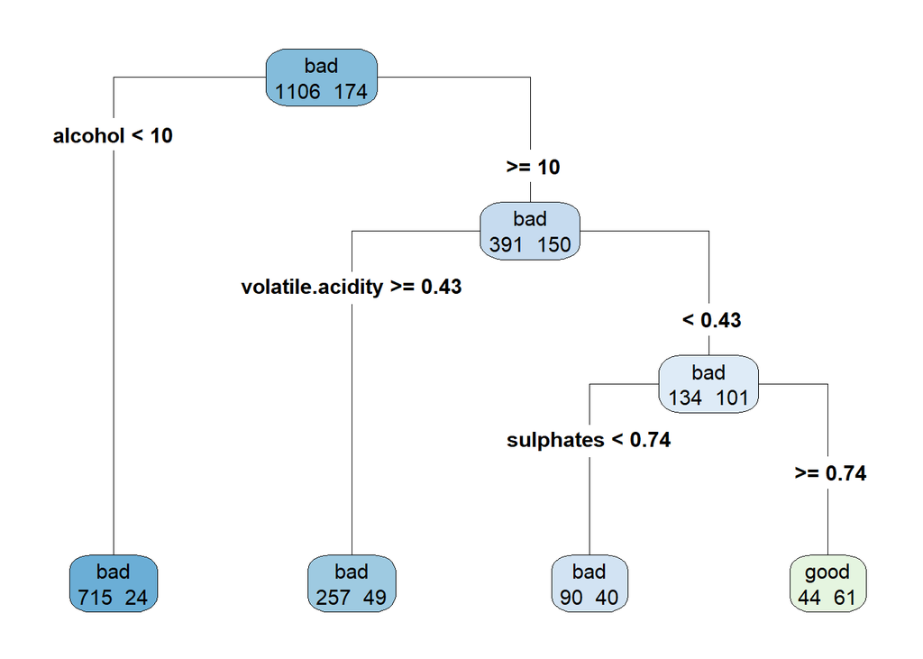

```r
rpart.plot(dt_fit_red_full, type=4, extra=1)
```

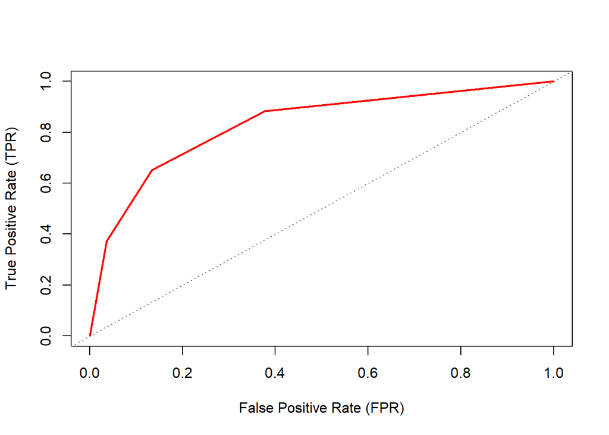

```r
dt_prediction_red_full <- predict(dt_fit_red_full,
                                  testdata_red_full[, !(names(data_red_wine_labelled) %in% c('label', 'label_binary'))],
                                  type='prob')

dt_pred_red_full <- prediction(dt_prediction_red_full[, 2], testdata_red_full$label)

dt_perf_red_full <- performance(dt_pred_red_full, "tpr", "fpr")


plot(dt_perf_red_full, col="red", lwd=2, xlab="False Positive Rate (FPR)", ylab="True Positive Rate (TPR)")
abline(a=0, b=1, col="gray50", lty=3)
```

```r
dt_auc_red_full <- performance(dt_pred_red_full, "auc")
dt_auc_red_full <- unlist(slot(dt_auc_red_full,"y.values"))
dt_auc_red_full
```

```
## [1] 0.8300472
```

```r
# White wine (full dataset)
dt_fit_white_full  <- rpart(label ~ fixed.acidity + volatile.acidity + citric.acid + residual.sugar + chlorides + free.sulfur.dioxide + total.sulfur.dioxide + density + pH + sulphates + alcohol, data=traindata_white_full,control=rpart.control(minsplit=390), method="class",
                            parms=list(split='information'))
summary(dt_fit_white_full )
```

```
## Call:
## rpart(formula = label ~ fixed.acidity + volatile.acidity + citric.acid +
##     residual.sugar + chlorides + free.sulfur.dioxide + total.sulfur.dioxide +
##     density + pH + sulphates + alcohol, data = traindata_white_full,
##     method = "class", parms = list(split = "information"), control = rpart.control(minsplit = 390))
##   n= 3919
##
##           CP nsplit rel error    xerror       xstd
## 1 0.02515723      0 1.0000000 1.0000000 0.03039865
## 2 0.01179245      3 0.9245283 0.9316038 0.02961644
## 3 0.01000000      4 0.9127358 0.9540094 0.02987934
##
## Variable importance
##              alcohol              density            chlorides
##                   41                   24                   14
## total.sulfur.dioxide       residual.sugar            sulphates
##                    9                    7                    2
##     volatile.acidity  free.sulfur.dioxide
##                    1                    1
##
## Node number 1: 3919 observations,    complexity param=0.02515723
##   predicted class=bad   expected loss=0.2163817  P(node) =1
##     class counts:  3071   848
##    probabilities: 0.784 0.216
##   left son=2 (2297 obs) right son=3 (1622 obs)
##   Primary splits:
##       alcohol              < 10.625   to the left,  improve=233.72620, (0 missing)
##       density              < 0.992215 to the right, improve=166.06470, (0 missing)
##       chlorides            < 0.0395   to the right, improve=127.94500, (0 missing)
##       total.sulfur.dioxide < 171.5    to the right, improve= 71.21220, (0 missing)
##       residual.sugar       < 6.35     to the right, improve= 36.16577, (0 missing)
##   Surrogate splits:
##       density              < 0.992545 to the right, agree=0.851, adj=0.641, (0 split)
##       chlorides            < 0.0375   to the right, agree=0.745, adj=0.383, (0 split)
##       total.sulfur.dioxide < 132.5    to the right, agree=0.692, adj=0.256, (0 split)
##       residual.sugar       < 5.275    to the right, agree=0.676, adj=0.218, (0 split)
##       sulphates            < 0.375    to the right, agree=0.609, adj=0.055, (0 split)
##
## Node number 2: 2297 observations
##   predicted class=bad   expected loss=0.09708315  P(node) =0.5861189
```

[output cut: 59 more lines]

```
##
## Node number 15: 188 observations
##   predicted class=good  expected loss=0.3297872  P(node) =0.04797142
##     class counts:    62   126
##    probabilities: 0.330 0.670
##
## Node number 28: 139 observations
##   predicted class=bad   expected loss=0.3309353  P(node) =0.03546823
##     class counts:    93    46
##    probabilities: 0.669 0.331
##
## Node number 29: 352 observations
##   predicted class=good  expected loss=0.4857955  P(node) =0.08981883
##     class counts:   171   181
##    probabilities: 0.486 0.514
```

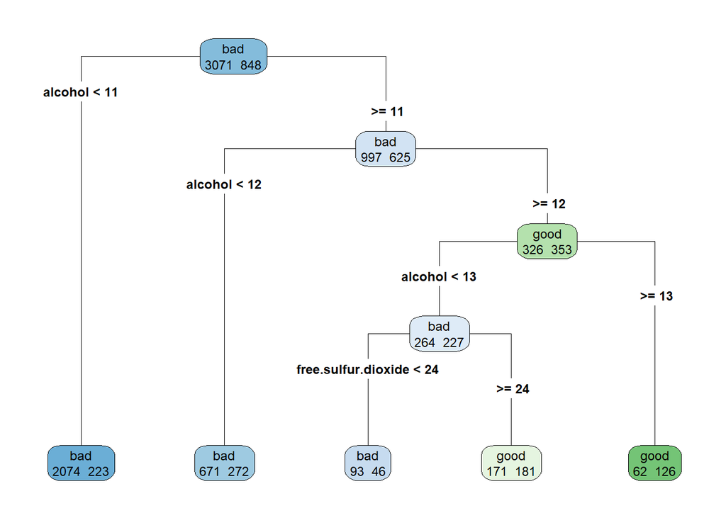

```r
rpart.plot(dt_fit_white_full , type=4, extra=1)
```

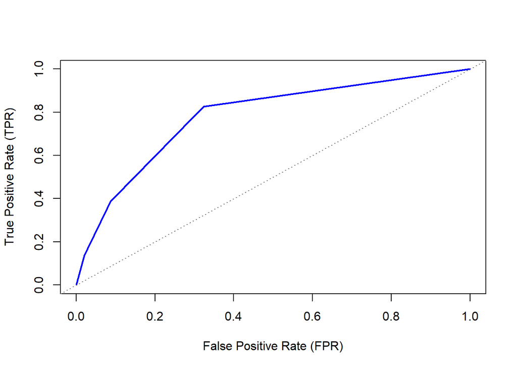

```r
dt_prediction_white_full <- predict(dt_fit_white_full,
                                    testdata_white_full[, !(names(data_white_wine_labelled) %in% c('label', 'label_binary'))],
                                    type='prob')

dt_pred_white_full <- prediction(dt_prediction_white_full[, 2], testdata_white_full$label)

dt_perf_white_full <- performance(dt_pred_white_full, "tpr", "fpr")


plot(dt_perf_white_full, col="blue", lwd=2, xlab="False Positive Rate (FPR)", ylab="True Positive Rate (TPR)")
abline(a=0, b=1, col="gray50", lty=3)
```

```r
dt_auc_white_full <- performance(dt_pred_white_full, "auc")
dt_auc_white_full <- unlist(slot(dt_auc_white_full,"y.values"))
dt_auc_white_full
```

```
## [1] 0.7795565
```

**Evaluating Classifiers**

Comparing AUC values:

```r
print(paste0("AUC of Naive Bayes Model (Red Wine Reduced Dataset):", nb_auc_red_reduced))
```

```
## [1] "AUC of Naive Bayes Model (Red Wine Reduced Dataset):0.872430064037746"
```

```r
print(paste0("AUC of Decision Tree Model (Red Wine Reduced Dataset):", dt_auc_red_reduced))
```

```
## [1] "AUC of Decision Tree Model (Red Wine Reduced Dataset):0.809234917425008"
```

```r
print(paste0("AUC of Logistic Regression Model (Red Wine Reduced Dataset):", lr_auc_red_reduced))
```

```
## [1] "AUC of Logistic Regression Model (Red Wine Reduced Dataset):0.8617"
```

```r
print(paste0("AUC of Naive Bayes Model (White Wine Reduced Dataset):", nb_auc_white_reduced))
```

```
## [1] "AUC of Naive Bayes Model (White Wine Reduced Dataset):0.703881823325381"
```

```r
# print(paste0("AUC of Decision Tree Model (White Wine Reduced Dataset):", dt_auc_white_reduced))
print(paste0("AUC of Logistic Regression Model (White Wine Reduced Dataset):", lr_auc_white_reduced))
```

```
## [1] "AUC of Logistic Regression Model (White Wine Reduced Dataset):0.751"
```

**Combining AOCs in single plot**

[figure not shown]

```r
par(mfrow=c(1,1))
plot(nb_perf_red_reduced, col="darkred", lwd=2, main="Wine Quality Label NB Model Prediction Perf (Full Dataset)", xlab="False Positive Rate (FPR)", ylab="True Positive Rate (TPR)")
abline(a=0, b=1, col="gray50", lty=3)

# par(new = TRUE)  # We draw on top of the existing plot.
# plot(perf, col = "red", lwd=2, main="", xlab="", ylab="")

par(new = TRUE)  # We draw on top of the existing plot.
plot(nb_perf_white_reduced, col = "blue", lwd=2, main="", xlab="", ylab="")

par(new = TRUE)  # We draw on top of the existing plot.
plot(dt_perf_red_reduced, col = "red", lwd=2, lty=2, main="", xlab="", ylab="")

# par(new = TRUE)  # We draw on top of the existing plot.
# plot(dt_perf_white_reduced, col = "blue", lwd=2, lty=2, main="", xlab="", ylab="")

par(new = TRUE)  # We draw on top of the existing plot.
plot(lr_perf_red_reduced, col = "red", lwd=2, lty=3, main="", xlab="", ylab="")

par(new = TRUE)  # We draw on top of the existing plot.
plot(lr_perf_white_reduced, col = "darkblue", lwd=2, lty=3, main="", xlab="", ylab="")

legend("topright",
       legend = c("Red Wine (NB)", "White Wine(NB)", "Red Wine (DT)", "White Wine(DT)", "Red Wine (LR)", "White Wine(LR)"),
       col = c("darkred", "darkblue", "red", "blue", "red", "blue"),
       lty = c(1, 1, 2, 2, 3, 3))
```

**Stepwise Regression**

We use stepwise regression using logistic regression focusing on p-values in order to determine the significant variables that affect the quality of wine (using quality above median as the binary response variable)

Since we use logistic regression using stepwise regression, we must make sure that variables are independent from one another, i.e none of the variables are heavily correlated with each other, so we use the reduced predictor set as explained in our EDA.

We want the most significant variables, so the p-value threshold is set at 0.001. Both backward elimination and forward selection are considered.

**Red Wine**

data_redwine_reduced_labelled

**Back Elimination**

```r
red_new_lr <- glm(formula = data_redwine_reduced_labelled$label_binary ~
                    data_redwine_reduced_labelled$citric.acid
                  + data_redwine_reduced_labelled$residual.sugar + data_redwine_reduced_labelled$chlorides + data_redwine_reduced_labelled$free.sulfur.dioxide
                  + data_redwine_reduced_labelled$sulphates + data_redwine_reduced_labelled$alcohol,
                  family = binomial(link="logit"))

summary(red_new_lr)
```

```
##
## Call:
## glm(formula = data_redwine_reduced_labelled$label_binary ~ data_redwine_reduced_labelled$citric.acid +
##     data_redwine_reduced_labelled$residual.sugar + data_redwine_reduced_labelled$chlorides +
##     data_redwine_reduced_labelled$free.sulfur.dioxide + data_redwine_reduced_labelled$sulphates +
##     data_redwine_reduced_labelled$alcohol, family = binomial(link = "logit"))
##
## Deviance Residuals:
##     Min       1Q   Median       3Q      Max
## -2.5806  -0.4543  -0.2477  -0.1633   2.8974
##
## Coefficients:
##                                                     Estimate Std. Error z value
## (Intercept)                                       -14.403289   1.108754 -12.991
## data_redwine_reduced_labelled$citric.acid           2.650669   0.470346   5.636
## data_redwine_reduced_labelled$residual.sugar        0.031127   0.064625   0.482
## data_redwine_reduced_labelled$chlorides           -12.443310   3.576709  -3.479
## data_redwine_reduced_labelled$free.sulfur.dioxide  -0.020003   0.008916  -2.243
## data_redwine_reduced_labelled$sulphates             3.376231   0.490867   6.878
## data_redwine_reduced_labelled$alcohol               0.975752   0.083053  11.749
##                                                   Pr(>|z|)
## (Intercept)                                        < 2e-16 ***
## data_redwine_reduced_labelled$citric.acid         1.74e-08 ***
## data_redwine_reduced_labelled$residual.sugar      0.630051
## data_redwine_reduced_labelled$chlorides           0.000503 ***
## data_redwine_reduced_labelled$free.sulfur.dioxide 0.024871 *
## data_redwine_reduced_labelled$sulphates           6.07e-12 ***
## data_redwine_reduced_labelled$alcohol              < 2e-16 ***
## ---
## Signif. codes:  0 '***' 0.001 '**' 0.01 '*' 0.05 '.' 0.1 ' ' 1
##
## (Dispersion parameter for binomial family taken to be 1)
##
##     Null deviance: 1269.92  on 1598  degrees of freedom
## Residual deviance:  918.25  on 1592  degrees of freedom
## AIC: 932.25
##
## Number of Fisher Scoring iterations: 6
```

As we can see residual.sugar has the highest p-val of 0.630051, so we remove it.

```r
red_new_lr_2 <- glm(formula = data_redwine_reduced_labelled$label_binary ~
                      data_redwine_reduced_labelled$citric.acid + data_redwine_reduced_labelled$chlorides + data_redwine_reduced_labelled$free.sulfur.dioxide
                    + data_redwine_reduced_labelled$sulphates + data_redwine_reduced_labelled$alcohol,
                    family = binomial(link="logit"))

summary(red_new_lr_2)
```

```
##
## Call:
## glm(formula = data_redwine_reduced_labelled$label_binary ~ data_redwine_reduced_labelled$citric.acid +
##     data_redwine_reduced_labelled$chlorides + data_redwine_reduced_labelled$free.sulfur.dioxide +
##     data_redwine_reduced_labelled$sulphates + data_redwine_reduced_labelled$alcohol,
##     family = binomial(link = "logit"))
##
## Deviance Residuals:
##     Min       1Q   Median       3Q      Max
## -2.5327  -0.4561  -0.2475  -0.1635   2.8974
##
## Coefficients:
##                                                     Estimate Std. Error z value
## (Intercept)                                       -14.365245   1.102957 -13.024
## data_redwine_reduced_labelled$citric.acid           2.698825   0.459721   5.871
## data_redwine_reduced_labelled$chlorides           -12.325562   3.545171  -3.477
## data_redwine_reduced_labelled$free.sulfur.dioxide  -0.019790   0.008903  -2.223
## data_redwine_reduced_labelled$sulphates             3.355766   0.488806   6.865
## data_redwine_reduced_labelled$alcohol               0.978315   0.082841  11.810
##                                                   Pr(>|z|)
## (Intercept)                                        < 2e-16 ***
## data_redwine_reduced_labelled$citric.acid         4.34e-09 ***
## data_redwine_reduced_labelled$chlorides           0.000508 ***
## data_redwine_reduced_labelled$free.sulfur.dioxide 0.026230 *
## data_redwine_reduced_labelled$sulphates           6.64e-12 ***
## data_redwine_reduced_labelled$alcohol              < 2e-16 ***
## ---
## Signif. codes:  0 '***' 0.001 '**' 0.01 '*' 0.05 '.' 0.1 ' ' 1
##
## (Dispersion parameter for binomial family taken to be 1)
##
##     Null deviance: 1269.92  on 1598  degrees of freedom
## Residual deviance:  918.48  on 1593  degrees of freedom
## AIC: 930.48
##
## Number of Fisher Scoring iterations: 6
```

As we can see free.sulfur.dioxide has the highest p-val of 0.026230, so we remove it.

```r
red_new_lr_3 <- glm(formula = data_redwine_reduced_labelled$label_binary ~
                      data_redwine_reduced_labelled$citric.acid + data_redwine_reduced_labelled$chlorides
                    + data_redwine_reduced_labelled$sulphates + data_redwine_reduced_labelled$alcohol,
                    family = binomial(link="logit"))

summary(red_new_lr_3)
```

```
##
## Call:
## glm(formula = data_redwine_reduced_labelled$label_binary ~ data_redwine_reduced_labelled$citric.acid +
##     data_redwine_reduced_labelled$chlorides + data_redwine_reduced_labelled$sulphates +
##     data_redwine_reduced_labelled$alcohol, family = binomial(link = "logit"))
##
## Deviance Residuals:
##     Min       1Q   Median       3Q      Max
## -2.6098  -0.4688  -0.2541  -0.1633   2.9498
##
## Coefficients:
##                                            Estimate Std. Error z value Pr(>|z|)
## (Intercept)                               -14.72657    1.09046 -13.505  < 2e-16
## data_redwine_reduced_labelled$citric.acid   2.84374    0.45755   6.215 5.13e-10
## data_redwine_reduced_labelled$chlorides   -11.75920    3.43012  -3.428 0.000608
## data_redwine_reduced_labelled$sulphates     3.19535    0.48095   6.644 3.06e-11
## data_redwine_reduced_labelled$alcohol       0.98623    0.08284  11.905  < 2e-16
##
## (Intercept)                               ***
## data_redwine_reduced_labelled$citric.acid ***
## data_redwine_reduced_labelled$chlorides   ***
## data_redwine_reduced_labelled$sulphates   ***
## data_redwine_reduced_labelled$alcohol     ***
## ---
## Signif. codes:  0 '***' 0.001 '**' 0.01 '*' 0.05 '.' 0.1 ' ' 1
##
## (Dispersion parameter for binomial family taken to be 1)
##
##     Null deviance: 1269.92  on 1598  degrees of freedom
## Residual deviance:  923.63  on 1594  degrees of freedom
## AIC: 933.63
##
## Number of Fisher Scoring iterations: 6
```

Significant variables: - citric.acid - chlorides - sulphates - alcohol

**Forward Selection**

```r
red_lr_new_fs1_1 <- glm(formula = data_redwine_reduced_labelled$label_binary ~ data_redwine_reduced_labelled$citric.acid,
                        family = binomial(link="logit"))

red_lr_new_fs1_2 <- glm(formula = data_redwine_reduced_labelled$label_binary ~ data_redwine_reduced_labelled$residual.sugar,
                        family = binomial(link="logit"))

red_lr_new_fs1_3 <- glm(formula = data_redwine_reduced_labelled$label_binary ~ data_redwine_reduced_labelled$chlorides,
                        family = binomial(link="logit"))

red_lr_new_fs1_4 <- glm(formula = data_redwine_reduced_labelled$label_binary ~ data_redwine_reduced_labelled$free.sulfur.dioxide,
                        family = binomial(link="logit"))

red_lr_new_fs1_5 <- glm(formula = data_redwine_reduced_labelled$label_binary ~ data_redwine_reduced_labelled$sulphates,
                        family = binomial(link="logit"))

red_lr_new_fs1_6 <- glm(formula = data_redwine_reduced_labelled$label_binary ~ data_redwine_reduced_labelled$alcohol,
                        family = binomial(link="logit"))

summary(red_lr_new_fs1_1)$coef
```

```
##                                            Estimate Std. Error    z value
## (Intercept)                               -2.861731  0.1571348 -18.211955
## data_redwine_reduced_labelled$citric.acid  3.209381  0.3875700   8.280776
##                                               Pr(>|z|)
## (Intercept)                               4.148644e-74
## data_redwine_reduced_labelled$citric.acid 1.223749e-16
```

```r
summary(red_lr_new_fs1_2)$coef
```

```
##                                                 Estimate Std. Error    z value
## (Intercept)                                  -2.06570423 0.13762945 -15.009173
## data_redwine_reduced_labelled$residual.sugar  0.08238545 0.04375419   1.882916
##                                                  Pr(>|z|)
## (Intercept)                                  6.393974e-51
## data_redwine_reduced_labelled$residual.sugar 5.971181e-02
```

```r
summary(red_lr_new_fs1_3)$coef
```

```
##                                           Estimate Std. Error   z value
## (Intercept)                              -0.390436  0.3239833 -1.205111
## data_redwine_reduced_labelled$chlorides -18.202353  4.1151963 -4.423204
##                                             Pr(>|z|)
## (Intercept)                             2.281603e-01
## data_redwine_reduced_labelled$chlorides 9.724784e-06
```

```r
summary(red_lr_new_fs1_4)$coef
```

```
##                                                      Estimate  Std. Error
## (Intercept)                                       -1.51529114 0.133252373
## data_redwine_reduced_labelled$free.sulfur.dioxide -0.02236819 0.007827782
##                                                      z value     Pr(>|z|)
## (Intercept)                                       -11.371588 5.792376e-30
## data_redwine_reduced_labelled$free.sulfur.dioxide  -2.857539 4.269397e-03
```

```r
summary(red_lr_new_fs1_5)$coef
```

```
##                                          Estimate Std. Error    z value
## (Intercept)                             -3.696673  0.2790006 -13.249698
## data_redwine_reduced_labelled$sulphates  2.694416  0.3810194   7.071597
##                                             Pr(>|z|)
## (Intercept)                             4.530196e-40
## data_redwine_reduced_labelled$sulphates 1.531605e-12
```

```r
summary(red_lr_new_fs1_6)$coef
```

```
##                                        Estimate Std. Error   z value
## (Intercept)                           -13.23466 0.84022125 -15.75140
## data_redwine_reduced_labelled$alcohol   1.05057 0.07486283  14.03326
##                                           Pr(>|z|)
## (Intercept)                           6.717456e-56
## data_redwine_reduced_labelled$alcohol 9.756085e-45
```

As we can see alcohol has the lowest p-val of 9.756085e-45, so we include it.

```r
red_lr_new_fs2_1 <- glm(formula = data_redwine_reduced_labelled$label_binary ~ data_redwine_reduced_labelled$alcohol + data_redwine_reduced_labelled$citric.acid,
                        family = binomial(link="logit"))

red_lr_new_fs2_2 <- glm(formula = data_redwine_reduced_labelled$label_binary ~ data_redwine_reduced_labelled$alcohol + data_redwine_reduced_labelled$residual.sugar,
                        family = binomial(link="logit"))

red_lr_new_fs2_3 <- glm(formula = data_redwine_reduced_labelled$label_binary ~ data_redwine_reduced_labelled$alcohol + data_redwine_reduced_labelled$chlorides,
                        family = binomial(link="logit"))

red_lr_new_fs2_4 <- glm(formula = data_redwine_reduced_labelled$label_binary ~ data_redwine_reduced_labelled$alcohol + data_redwine_reduced_labelled$free.sulfur.dioxide,
                        family = binomial(link="logit"))

red_lr_new_fs2_5 <- glm(formula = data_redwine_reduced_labelled$label_binary ~ data_redwine_reduced_labelled$alcohol + data_redwine_reduced_labelled$sulphates,
                        family = binomial(link="logit"))

summary(red_lr_new_fs2_1)$coef
```

```
##                                             Estimate Std. Error    z value
## (Intercept)                               -14.052684 0.88436667 -15.890110
## data_redwine_reduced_labelled$alcohol       1.038926 0.07667443  13.549835
## data_redwine_reduced_labelled$citric.acid   2.960759 0.41927114   7.061682
##                                               Pr(>|z|)
## (Intercept)                               7.419755e-57
## data_redwine_reduced_labelled$alcohol     7.940879e-42
## data_redwine_reduced_labelled$citric.acid 1.644996e-12
```

```r
summary(red_lr_new_fs2_2)$coef
```

```
##                                                  Estimate Std. Error    z value
## (Intercept)                                  -13.37146773 0.85032806 -15.725069
## data_redwine_reduced_labelled$alcohol          1.04693899 0.07485961  13.985366
## data_redwine_reduced_labelled$residual.sugar   0.06766884 0.05539129   1.221651
##                                                  Pr(>|z|)
## (Intercept)                                  1.018392e-55
## data_redwine_reduced_labelled$alcohol        1.914888e-44
## data_redwine_reduced_labelled$residual.sugar 2.218395e-01
```

```r
summary(red_lr_new_fs2_3)$coef
```

```
##                                           Estimate Std. Error    z value
## (Intercept)                             -12.688354 0.94848325 -13.377521
## data_redwine_reduced_labelled$alcohol     1.027297 0.07700302  13.340997
## data_redwine_reduced_labelled$chlorides  -3.607053 3.10247479  -1.162637
##                                             Pr(>|z|)
## (Intercept)                             8.183171e-41
## data_redwine_reduced_labelled$alcohol   1.336592e-40
## data_redwine_reduced_labelled$chlorides 2.449767e-01
```

```r
summary(red_lr_new_fs2_4)$coef
```

```
##                                                       Estimate  Std. Error
## (Intercept)                                       -12.89767973 0.851508522
## data_redwine_reduced_labelled$alcohol               1.04337014 0.074887913
## data_redwine_reduced_labelled$free.sulfur.dioxide  -0.01735816 0.008431011
##                                                      z value     Pr(>|z|)
## (Intercept)                                       -15.146859 7.947485e-52
## data_redwine_reduced_labelled$alcohol              13.932424 4.024622e-44
## data_redwine_reduced_labelled$free.sulfur.dioxide  -2.058847 3.950893e-02
```

```r
summary(red_lr_new_fs2_5)$coef
```

```
##                                           Estimate Std. Error    z value
## (Intercept)                             -15.860067 0.99419063 -15.952742
## data_redwine_reduced_labelled$alcohol     1.090337 0.07916258  13.773393
## data_redwine_reduced_labelled$sulphates   3.144493 0.42615799   7.378703
##                                             Pr(>|z|)
## (Intercept)                             2.726560e-57
## data_redwine_reduced_labelled$alcohol   3.684896e-43
## data_redwine_reduced_labelled$sulphates 1.598385e-13
```

As we can see sulphates has the lowest p-val of 1.598385e-13, so we include it.

```r
red_lr_new_fs3_1 <- glm(formula = data_redwine_reduced_labelled$label_binary ~ data_redwine_reduced_labelled$alcohol + data_redwine_reduced_labelled$sulphates +  data_redwine_reduced_labelled$citric.acid,
                        family = binomial(link="logit"))

red_lr_new_fs3_2 <- glm(formula = data_redwine_reduced_labelled$label_binary ~ data_redwine_reduced_labelled$alcohol + data_redwine_reduced_labelled$sulphates +  data_redwine_reduced_labelled$residual.sugar,
                        family = binomial(link="logit"))

red_lr_new_fs3_3 <- glm(formula = data_redwine_reduced_labelled$label_binary ~ data_redwine_reduced_labelled$alcohol + data_redwine_reduced_labelled$sulphates +  data_redwine_reduced_labelled$chlorides,
                        family = binomial(link="logit"))

red_lr_new_fs3_4 <- glm(formula = data_redwine_reduced_labelled$label_binary ~ data_redwine_reduced_labelled$alcohol + data_redwine_reduced_labelled$sulphates +  data_redwine_reduced_labelled$free.sulfur.dioxide,
                        family = binomial(link="logit"))


summary(red_lr_new_fs3_1)$coef
```

```
##                                             Estimate Std. Error    z value
## (Intercept)                               -16.068750 1.01590661 -15.817153
## data_redwine_reduced_labelled$alcohol       1.077530 0.07994843  13.477808
## data_redwine_reduced_labelled$sulphates     2.529062 0.44061020   5.739908
## data_redwine_reduced_labelled$citric.acid   2.399661 0.43650497   5.497443
##                                               Pr(>|z|)
## (Intercept)                               2.369689e-56
## data_redwine_reduced_labelled$alcohol     2.112917e-41
## data_redwine_reduced_labelled$sulphates   9.472809e-09
## data_redwine_reduced_labelled$citric.acid 3.853376e-08
```

```r
summary(red_lr_new_fs3_2)$coef
```

```
##                                                 Estimate Std. Error    z value
## (Intercept)                                  -16.0524804 1.00843682 -15.918182
## data_redwine_reduced_labelled$alcohol          1.0869830 0.07915845  13.731736
## data_redwine_reduced_labelled$sulphates        3.1678986 0.42774908   7.405974
## data_redwine_reduced_labelled$residual.sugar   0.0813842 0.05693833   1.429340
##                                                  Pr(>|z|)
## (Intercept)                                  4.739523e-57
## data_redwine_reduced_labelled$alcohol        6.554383e-43
## data_redwine_reduced_labelled$sulphates      1.301911e-13
## data_redwine_reduced_labelled$residual.sugar 1.529067e-01
```

```r
summary(red_lr_new_fs3_3)$coef
```

```
##                                           Estimate Std. Error    z value
## (Intercept)                             -14.898718 1.05392887 -14.136360
## data_redwine_reduced_labelled$alcohol     1.025799 0.08165339  12.562841
## data_redwine_reduced_labelled$sulphates   3.720786 0.48047416   7.743988
## data_redwine_reduced_labelled$chlorides  -7.980316 2.87455650  -2.776190
##                                             Pr(>|z|)
## (Intercept)                             2.267107e-45
## data_redwine_reduced_labelled$alcohol   3.379746e-36
## data_redwine_reduced_labelled$sulphates 9.634592e-15
## data_redwine_reduced_labelled$chlorides 5.500001e-03
```

```r
summary(red_lr_new_fs3_4)$coef
```

```
##                                                      Estimate  Std. Error
## (Intercept)                                       -15.5279190 1.000274930
## data_redwine_reduced_labelled$alcohol               1.0836960 0.079280347
## data_redwine_reduced_labelled$sulphates             3.2831240 0.430336294
## data_redwine_reduced_labelled$free.sulfur.dioxide  -0.0240922 0.008787798
##                                                      z value     Pr(>|z|)
## (Intercept)                                       -15.523651 2.399979e-54
## data_redwine_reduced_labelled$alcohol              13.669163 1.551701e-42
## data_redwine_reduced_labelled$sulphates             7.629205 2.362049e-14
## data_redwine_reduced_labelled$free.sulfur.dioxide  -2.741552 6.114973e-03
```

As we can see citric.acid has the lowest p-val of 3.853376e-08, so we include it.

```r
red_lr_new_fs4_1 <- glm(formula = data_redwine_reduced_labelled$label_binary ~ data_redwine_reduced_labelled$alcohol + data_redwine_reduced_labelled$sulphates + data_redwine_reduced_labelled$citric.acid +  data_redwine_reduced_labelled$residual.sugar,
                        family = binomial(link="logit"))

red_lr_new_fs4_2 <- glm(formula = data_redwine_reduced_labelled$label_binary ~ data_redwine_reduced_labelled$alcohol + data_redwine_reduced_labelled$sulphates + data_redwine_reduced_labelled$citric.acid +  data_redwine_reduced_labelled$chlorides,
                        family = binomial(link="logit"))

red_lr_new_fs4_3 <- glm(formula = data_redwine_reduced_labelled$label_binary ~ data_redwine_reduced_labelled$alcohol + data_redwine_reduced_labelled$sulphates + data_redwine_reduced_labelled$citric.acid +  data_redwine_reduced_labelled$free.sulfur.dioxide,
                        family = binomial(link="logit"))


summary(red_lr_new_fs4_1)$coef
```

```
##                                                  Estimate Std. Error
## (Intercept)                                  -16.09245495 1.02538769
## data_redwine_reduced_labelled$alcohol          1.07703941 0.07999495
## data_redwine_reduced_labelled$sulphates        2.53693051 0.44303437
## data_redwine_reduced_labelled$citric.acid      2.38288714 0.44670246
## data_redwine_reduced_labelled$residual.sugar   0.01127305 0.06381395
##                                                  z value     Pr(>|z|)
## (Intercept)                                  -15.6940200 1.661893e-55
## data_redwine_reduced_labelled$alcohol         13.4638421 2.552887e-41
## data_redwine_reduced_labelled$sulphates        5.7262611 1.026681e-08
## data_redwine_reduced_labelled$citric.acid      5.3343944 9.586394e-08
## data_redwine_reduced_labelled$residual.sugar   0.1766549 8.597794e-01
```

```r
summary(red_lr_new_fs4_2)$coef
```

```
##                                              Estimate Std. Error    z value
## (Intercept)                               -14.7265723  1.0904622 -13.504890
## data_redwine_reduced_labelled$alcohol       0.9862251  0.0828439  11.904619
## data_redwine_reduced_labelled$sulphates     3.1953460  0.4809525   6.643788
## data_redwine_reduced_labelled$citric.acid   2.8437433  0.4575547   6.215089
## data_redwine_reduced_labelled$chlorides   -11.7592032  3.4301190  -3.428220
##                                               Pr(>|z|)
## (Intercept)                               1.463328e-41
## data_redwine_reduced_labelled$alcohol     1.119740e-32
## data_redwine_reduced_labelled$sulphates   3.057230e-11
## data_redwine_reduced_labelled$citric.acid 5.129550e-10
## data_redwine_reduced_labelled$chlorides   6.075525e-04
```

```r
summary(red_lr_new_fs4_3)$coef
```

```
##                                                       Estimate  Std. Error
## (Intercept)                                       -15.80134270 1.022737890
## data_redwine_reduced_labelled$alcohol               1.07247216 0.080038765
## data_redwine_reduced_labelled$sulphates             2.65738674 0.445126973
## data_redwine_reduced_labelled$citric.acid           2.26280739 0.439923778
## data_redwine_reduced_labelled$free.sulfur.dioxide  -0.01728409 0.008805842
##                                                      z value     Pr(>|z|)
## (Intercept)                                       -15.450041 7.539506e-54
## data_redwine_reduced_labelled$alcohol              13.399409 6.094635e-41
## data_redwine_reduced_labelled$sulphates             5.969952 2.373232e-09
## data_redwine_reduced_labelled$citric.acid           5.143635 2.694727e-07
## data_redwine_reduced_labelled$free.sulfur.dioxide  -1.962798 4.966965e-02
```

As we can see chlorides has the lowest p-val of 6.075525e-04, so we include it.

```r
red_lr_new_fs5_1 <- glm(formula = data_redwine_reduced_labelled$label_binary ~ data_redwine_reduced_labelled$alcohol + data_redwine_reduced_labelled$sulphates + data_redwine_reduced_labelled$citric.acid + data_redwine_reduced_labelled$chlorides +  data_redwine_reduced_labelled$residual.sugar,
                        family = binomial(link="logit"))

red_lr_new_fs5_2 <- glm(formula = data_redwine_reduced_labelled$label_binary ~ data_redwine_reduced_labelled$alcohol + data_redwine_reduced_labelled$sulphates + data_redwine_reduced_labelled$citric.acid + data_redwine_reduced_labelled$chlorides +  data_redwine_reduced_labelled$free.sulfur.dioxide,
                        family = binomial(link="logit"))


summary(red_lr_new_fs5_1)$coef
```

```
##                                                  Estimate Std. Error
## (Intercept)                                  -14.76166802 1.09708151
## data_redwine_reduced_labelled$alcohol          0.98473937 0.08298161
## data_redwine_reduced_labelled$sulphates        3.20985154 0.48285885
## data_redwine_reduced_labelled$citric.acid      2.81023432 0.46696219
## data_redwine_reduced_labelled$chlorides      -11.84557305 3.45540631
## data_redwine_reduced_labelled$residual.sugar   0.02293995 0.06405785
##                                                  z value     Pr(>|z|)
## (Intercept)                                  -13.4553977 2.861951e-41
## data_redwine_reduced_labelled$alcohol         11.8669585 1.757412e-32
## data_redwine_reduced_labelled$sulphates        6.6475981 2.979145e-11
## data_redwine_reduced_labelled$citric.acid      6.0181196 1.764548e-09
## data_redwine_reduced_labelled$chlorides       -3.4281274 6.077602e-04
## data_redwine_reduced_labelled$residual.sugar   0.3581131 7.202587e-01
```

```r
summary(red_lr_new_fs5_2)$coef
```

```
##                                                       Estimate  Std. Error
## (Intercept)                                       -14.36524548 1.102957148
## data_redwine_reduced_labelled$alcohol               0.97831473 0.082841248
## data_redwine_reduced_labelled$sulphates             3.35576569 0.488806341
## data_redwine_reduced_labelled$citric.acid           2.69882466 0.459720863
## data_redwine_reduced_labelled$chlorides           -12.32556183 3.545171137
## data_redwine_reduced_labelled$free.sulfur.dioxide  -0.01979038 0.008903398
##                                                      z value     Pr(>|z|)
## (Intercept)                                       -13.024301 8.901291e-39
## data_redwine_reduced_labelled$alcohol              11.809512 3.485780e-32
## data_redwine_reduced_labelled$sulphates             6.865225 6.638636e-12
## data_redwine_reduced_labelled$citric.acid           5.870573 4.342928e-09
## data_redwine_reduced_labelled$chlorides            -3.476718 5.075906e-04
## data_redwine_reduced_labelled$free.sulfur.dioxide  -2.222790 2.622996e-02
```

As we can see, none of the variables have a p-value lower than 0.001, so we stop here.

Significant variables: - citric.acid - chlorides - sulphates - alcohol

**White Wine**

```r
white_lr_new_1 <- glm(formula = data_whitewine_reduced_labelled$label_binary ~
                      data_whitewine_reduced_labelled$fixed.acidity + data_whitewine_reduced_labelled$volatile.acidity +
                      data_whitewine_reduced_labelled$citric.acid + data_whitewine_reduced_labelled$residual.sugar + data_whitewine_reduced_labelled$chlorides +
                      data_whitewine_reduced_labelled$free.sulfur.dioxide +  data_whitewine_reduced_labelled$sulphates,
                    family = binomial(link="logit"))

summary(white_lr_new_1)
```

```
##
## Call:
## glm(formula = data_whitewine_reduced_labelled$label_binary ~
##     data_whitewine_reduced_labelled$fixed.acidity + data_whitewine_reduced_labelled$volatile.acidity +
##         data_whitewine_reduced_labelled$citric.acid + data_whitewine_reduced_labelled$residual.sugar +
##         data_whitewine_reduced_labelled$chlorides + data_whitewine_reduced_labelled$free.sulfur.dioxide +
##         data_whitewine_reduced_labelled$sulphates, family = binomial(link = "logit"))
##
## Deviance Residuals:
##     Min       1Q   Median       3Q      Max
## -1.5190  -0.7364  -0.5650  -0.2283   3.5933
##
## Coefficients:
##                                                       Estimate Std. Error
## (Intercept)                                           2.252605   0.385275
## data_whitewine_reduced_labelled$fixed.acidity        -0.157333   0.045381
## data_whitewine_reduced_labelled$volatile.acidity     -1.738417   0.402349
## data_whitewine_reduced_labelled$citric.acid          -0.291321   0.346914
## data_whitewine_reduced_labelled$residual.sugar       -0.032133   0.008523
## data_whitewine_reduced_labelled$chlorides           -57.497984   3.972277
## data_whitewine_reduced_labelled$free.sulfur.dioxide   0.003737   0.002249
## data_whitewine_reduced_labelled$sulphates             1.130551   0.303713
##                                                     z value Pr(>|z|)
## (Intercept)                                           5.847 5.01e-09 ***
## data_whitewine_reduced_labelled$fixed.acidity        -3.467 0.000526 ***
## data_whitewine_reduced_labelled$volatile.acidity     -4.321 1.56e-05 ***
## data_whitewine_reduced_labelled$citric.acid          -0.840 0.401049
## data_whitewine_reduced_labelled$residual.sugar       -3.770 0.000163 ***
## data_whitewine_reduced_labelled$chlorides           -14.475  < 2e-16 ***
## data_whitewine_reduced_labelled$free.sulfur.dioxide   1.661 0.096634 .
## data_whitewine_reduced_labelled$sulphates             3.722 0.000197 ***
## ---
## Signif. codes:  0 '***' 0.001 '**' 0.01 '*' 0.05 '.' 0.1 ' ' 1
##
## (Dispersion parameter for binomial family taken to be 1)
##
##     Null deviance: 5116.8  on 4897  degrees of freedom
## Residual deviance: 4695.8  on 4890  degrees of freedom
## AIC: 4711.8
##
## Number of Fisher Scoring iterations: 5
```

As we can see citric.acid has the highest p-val of 0.401049, so we remove it.

```r
white_lr_new_2 <- glm(formula = data_whitewine_reduced_labelled$label_binary ~
                        data_whitewine_reduced_labelled$fixed.acidity + data_whitewine_reduced_labelled$volatile.acidity +
                        data_whitewine_reduced_labelled$residual.sugar + data_whitewine_reduced_labelled$chlorides +
                        data_whitewine_reduced_labelled$free.sulfur.dioxide +  data_whitewine_reduced_labelled$sulphates,
                      family = binomial(link="logit"))

summary(white_lr_new_2)
```

```
##
## Call:
## glm(formula = data_whitewine_reduced_labelled$label_binary ~
##     data_whitewine_reduced_labelled$fixed.acidity + data_whitewine_reduced_labelled$volatile.acidity +
##         data_whitewine_reduced_labelled$residual.sugar + data_whitewine_reduced_labelled$chlorides +
##         data_whitewine_reduced_labelled$free.sulfur.dioxide +
##         data_whitewine_reduced_labelled$sulphates, family = binomial(link = "logit"))
##
## Deviance Residuals:
##     Min       1Q   Median       3Q      Max
## -1.5358  -0.7361  -0.5659  -0.2310   3.5685
##
## Coefficients:
##                                                       Estimate Std. Error
## (Intercept)                                           2.230804   0.384252
## data_whitewine_reduced_labelled$fixed.acidity        -0.168725   0.043345
## data_whitewine_reduced_labelled$volatile.acidity     -1.679593   0.396111
## data_whitewine_reduced_labelled$residual.sugar       -0.032726   0.008499
## data_whitewine_reduced_labelled$chlorides           -57.401688   3.969023
## data_whitewine_reduced_labelled$free.sulfur.dioxide   0.003639   0.002248
## data_whitewine_reduced_labelled$sulphates             1.111044   0.302808
##                                                     z value Pr(>|z|)
## (Intercept)                                           5.806 6.41e-09 ***
## data_whitewine_reduced_labelled$fixed.acidity        -3.893 9.92e-05 ***
## data_whitewine_reduced_labelled$volatile.acidity     -4.240 2.23e-05 ***
## data_whitewine_reduced_labelled$residual.sugar       -3.850 0.000118 ***
## data_whitewine_reduced_labelled$chlorides           -14.462  < 2e-16 ***
## data_whitewine_reduced_labelled$free.sulfur.dioxide   1.619 0.105479
## data_whitewine_reduced_labelled$sulphates             3.669 0.000243 ***
## ---
## Signif. codes:  0 '***' 0.001 '**' 0.01 '*' 0.05 '.' 0.1 ' ' 1
##
## (Dispersion parameter for binomial family taken to be 1)
##
##     Null deviance: 5116.8  on 4897  degrees of freedom
## Residual deviance: 4696.5  on 4891  degrees of freedom
## AIC: 4710.5
##
## Number of Fisher Scoring iterations: 5
```

As we can see free.sulfur.dioxide has the highest p-val of 0.105479, so we remove it.

```r
white_lr_new_3 <- glm(formula = data_whitewine_reduced_labelled$label_binary ~
                        data_whitewine_reduced_labelled$fixed.acidity + data_whitewine_reduced_labelled$volatile.acidity +
                        data_whitewine_reduced_labelled$residual.sugar + data_whitewine_reduced_labelled$chlorides +  data_whitewine_reduced_labelled$sulphates,
                      family = binomial(link="logit"))

summary(white_lr_new_3)
```

```
##
## Call:
## glm(formula = data_whitewine_reduced_labelled$label_binary ~
##     data_whitewine_reduced_labelled$fixed.acidity + data_whitewine_reduced_labelled$volatile.acidity +
##         data_whitewine_reduced_labelled$residual.sugar + data_whitewine_reduced_labelled$chlorides +
##         data_whitewine_reduced_labelled$sulphates, family = binomial(link = "logit"))
##
## Deviance Residuals:
##     Min       1Q   Median       3Q      Max
## -1.5533  -0.7373  -0.5638  -0.2288   3.5813
##
## Coefficients:
##                                                    Estimate Std. Error z value
## (Intercept)                                        2.349256   0.376844   6.234
## data_whitewine_reduced_labelled$fixed.acidity     -0.174425   0.043138  -4.043
## data_whitewine_reduced_labelled$volatile.acidity  -1.749178   0.393433  -4.446
## data_whitewine_reduced_labelled$residual.sugar    -0.028936   0.008142  -3.554
## data_whitewine_reduced_labelled$chlorides        -56.711066   3.929915 -14.431
## data_whitewine_reduced_labelled$sulphates          1.143687   0.302058   3.786
##                                                  Pr(>|z|)
## (Intercept)                                      4.55e-10 ***
## data_whitewine_reduced_labelled$fixed.acidity    5.27e-05 ***
## data_whitewine_reduced_labelled$volatile.acidity 8.75e-06 ***
## data_whitewine_reduced_labelled$residual.sugar   0.000379 ***
## data_whitewine_reduced_labelled$chlorides         < 2e-16 ***
## data_whitewine_reduced_labelled$sulphates        0.000153 ***
## ---
## Signif. codes:  0 '***' 0.001 '**' 0.01 '*' 0.05 '.' 0.1 ' ' 1
##
## (Dispersion parameter for binomial family taken to be 1)
##
##     Null deviance: 5116.8  on 4897  degrees of freedom
## Residual deviance: 4699.1  on 4892  degrees of freedom
## AIC: 4711.1
##
## Number of Fisher Scoring iterations: 5
```

Significant variables: - fixed.acidity - volatile.acidity - residual.sugar - chlorides - sulphates

**Forward Selection**

```r
white_lr_new_fs1_1 <- glm(formula = data_whitewine_reduced_labelled$label_binary ~ data_whitewine_reduced_labelled$fixed.acidity,
                          family = binomial(link="logit"))

white_lr_new_fs1_2 <- glm(formula = data_whitewine_reduced_labelled$label_binary ~ data_whitewine_reduced_labelled$volatile.acidity,
                          family = binomial(link="logit"))

white_lr_new_fs1_3 <- glm(formula = data_whitewine_reduced_labelled$label_binary ~ data_whitewine_reduced_labelled$citric.acid,
                          family = binomial(link="logit"))

white_lr_new_fs1_4 <- glm(formula = data_whitewine_reduced_labelled$label_binary ~ data_whitewine_reduced_labelled$residual.sugar,
                          family = binomial(link="logit"))

white_lr_new_fs1_5 <- glm(formula = data_whitewine_reduced_labelled$label_binary ~ data_whitewine_reduced_labelled$chlorides,
                          family = binomial(link="logit"))

white_lr_new_fs1_6 <- glm(formula = data_whitewine_reduced_labelled$label_binary ~ data_whitewine_reduced_labelled$free.sulfur.dioxide,
                          family = binomial(link="logit"))

white_lr_new_fs1_7 <- glm(formula = data_whitewine_reduced_labelled$label_binary ~ data_whitewine_reduced_labelled$sulphates,
                          family = binomial(link="logit"))

summary(white_lr_new_fs1_1)$coef
```

```
##                                                 Estimate Std. Error   z value
## (Intercept)                                    0.3649685  0.2930607  1.245368
## data_whitewine_reduced_labelled$fixed.acidity -0.2426636  0.0430520 -5.636524
##                                                   Pr(>|z|)
## (Intercept)                                   2.129964e-01
## data_whitewine_reduced_labelled$fixed.acidity 1.735170e-08
```

```r
summary(white_lr_new_fs1_2)$coef
```

```
##                                                    Estimate Std. Error
## (Intercept)                                      -0.8050328  0.1066823
## data_whitewine_reduced_labelled$volatile.acidity -1.7628065  0.3758387
##                                                    z value     Pr(>|z|)
## (Intercept)                                      -7.546078 4.485630e-14
## data_whitewine_reduced_labelled$volatile.acidity -4.690327 2.727689e-06
```

```r
summary(white_lr_new_fs1_3)$coef
```

```
##                                               Estimate Std. Error   z value
## (Intercept)                                 -1.0438859  0.1033727 -10.09828
## data_whitewine_reduced_labelled$citric.acid -0.7331738  0.2967174  -2.47095
##                                                 Pr(>|z|)
## (Intercept)                                 5.622114e-24
## data_whitewine_reduced_labelled$citric.acid 1.347548e-02
```

```r
summary(white_lr_new_fs1_4)$coef
```

```
##                                                   Estimate  Std. Error
## (Intercept)                                    -0.91701409 0.054677615
## data_whitewine_reduced_labelled$residual.sugar -0.06215676 0.007621927
##                                                   z value     Pr(>|z|)
## (Intercept)                                    -16.771289 3.958262e-63
## data_whitewine_reduced_labelled$residual.sugar  -8.154993 3.492009e-16
```

```r
summary(white_lr_new_fs1_5)$coef
```

```
##                                             Estimate Std. Error    z value
## (Intercept)                                 1.185817  0.1518908   7.807034
## data_whitewine_reduced_labelled$chlorides -59.372790  3.7355361 -15.894048
##                                               Pr(>|z|)
## (Intercept)                               5.854968e-15
## data_whitewine_reduced_labelled$chlorides 6.967899e-57
```

```r
summary(white_lr_new_fs1_6)$coef
```

```
##                                                         Estimate  Std. Error
## (Intercept)                                         -1.166781659 0.080464419
## data_whitewine_reduced_labelled$free.sulfur.dioxide -0.003422994 0.002089073
##                                                        z value     Pr(>|z|)
## (Intercept)                                         -14.500591 1.201107e-47
## data_whitewine_reduced_labelled$free.sulfur.dioxide  -1.638523 1.013126e-01
```

```r
summary(white_lr_new_fs1_7)$coef
```

```
##                                            Estimate Std. Error    z value
## (Intercept)                               -1.770770  0.1512616 -11.706678
## data_whitewine_reduced_labelled$sulphates  0.981025  0.2962019   3.312014
##                                               Pr(>|z|)
## (Intercept)                               1.178061e-31
## data_whitewine_reduced_labelled$sulphates 9.262688e-04
```

As we can see chlorides has the lowest p-val of 6.967899e-57, so we include it.

```r
white_lr_new_fs2_1 <- glm(formula = data_whitewine_reduced_labelled$label_binary ~ data_whitewine_reduced_labelled$chlorides + data_whitewine_reduced_labelled$fixed.acidity,
                          family = binomial(link="logit"))

white_lr_new_fs2_2 <- glm(formula = data_whitewine_reduced_labelled$label_binary ~ data_whitewine_reduced_labelled$chlorides + data_whitewine_reduced_labelled$volatile.acidity,
                          family = binomial(link="logit"))

white_lr_new_fs2_3 <- glm(formula = data_whitewine_reduced_labelled$label_binary ~ data_whitewine_reduced_labelled$chlorides + data_whitewine_reduced_labelled$citric.acid,
                          family = binomial(link="logit"))

white_lr_new_fs2_4 <- glm(formula = data_whitewine_reduced_labelled$label_binary ~ data_whitewine_reduced_labelled$chlorides + data_whitewine_reduced_labelled$residual.sugar,
                          family = binomial(link="logit"))

white_lr_new_fs2_5 <- glm(formula = data_whitewine_reduced_labelled$label_binary ~ data_whitewine_reduced_labelled$chlorides + data_whitewine_reduced_labelled$free.sulfur.dioxide,
                          family = binomial(link="logit"))

white_lr_new_fs2_6 <- glm(formula = data_whitewine_reduced_labelled$label_binary ~ data_whitewine_reduced_labelled$chlorides +  data_whitewine_reduced_labelled$sulphates,
                          family = binomial(link="logit"))

summary(white_lr_new_fs2_1)$coef
```

```
##                                                  Estimate Std. Error    z value
## (Intercept)                                     2.3815023 0.31744117   7.502185
## data_whitewine_reduced_labelled$chlorides     -58.0734708 3.74380252 -15.511895
## data_whitewine_reduced_labelled$fixed.acidity  -0.1833189 0.04274359  -4.288804
##                                                   Pr(>|z|)
## (Intercept)                                   6.276283e-14
## data_whitewine_reduced_labelled$chlorides     2.882456e-54
## data_whitewine_reduced_labelled$fixed.acidity 1.796381e-05
```

```r
summary(white_lr_new_fs2_2)$coef
```

```
##                                                    Estimate Std. Error
## (Intercept)                                        1.745379  0.1926771
## data_whitewine_reduced_labelled$chlorides        -60.486196  3.7829969
## data_whitewine_reduced_labelled$volatile.acidity  -1.891691  0.3925510
##                                                     z value     Pr(>|z|)
## (Intercept)                                        9.058570 1.321721e-19
## data_whitewine_reduced_labelled$chlorides        -15.988963 1.525498e-57
## data_whitewine_reduced_labelled$volatile.acidity  -4.818967 1.443031e-06
```

```r
summary(white_lr_new_fs2_3)$coef
```

```
##                                                Estimate Std. Error    z value
## (Intercept)                                   1.3065633  0.1800580   7.256346
## data_whitewine_reduced_labelled$chlorides   -59.1752674  3.7360278 -15.839086
## data_whitewine_reduced_labelled$citric.acid  -0.3901545  0.3119171  -1.250827
##                                                 Pr(>|z|)
## (Intercept)                                 3.976857e-13
## data_whitewine_reduced_labelled$chlorides   1.672332e-56
## data_whitewine_reduced_labelled$citric.acid 2.109974e-01
```

```r
summary(white_lr_new_fs2_4)$coef
```

```
##                                                    Estimate  Std. Error
## (Intercept)                                      1.22177633 0.151417259
## data_whitewine_reduced_labelled$chlorides      -54.94345325 3.813705782
## data_whitewine_reduced_labelled$residual.sugar  -0.03649588 0.008070705
##                                                   z value     Pr(>|z|)
## (Intercept)                                      8.068937 7.091283e-16
## data_whitewine_reduced_labelled$chlorides      -14.406841 4.686604e-47
## data_whitewine_reduced_labelled$residual.sugar  -4.522019 6.125268e-06
```

```r
summary(white_lr_new_fs2_5)$coef
```

```
##                                                          Estimate  Std. Error
## (Intercept)                                           1.120614186 0.158890039
## data_whitewine_reduced_labelled$chlorides           -60.404743716 3.822414388
## data_whitewine_reduced_labelled$free.sulfur.dioxide   0.003058127 0.002140933
##                                                        z value     Pr(>|z|)
## (Intercept)                                           7.052766 1.753963e-12
## data_whitewine_reduced_labelled$chlorides           -15.802772 2.977307e-56
## data_whitewine_reduced_labelled$free.sulfur.dioxide   1.428408 1.531744e-01
```

```r
summary(white_lr_new_fs2_6)$coef
```

```
##                                              Estimate Std. Error    z value
## (Intercept)                                 0.5849592  0.2023250   2.891185
## data_whitewine_reduced_labelled$chlorides -60.9418598  3.7821418 -16.113055
## data_whitewine_reduced_labelled$sulphates   1.3469785  0.2982418   4.516397
##                                               Pr(>|z|)
## (Intercept)                               3.837916e-03
## data_whitewine_reduced_labelled$chlorides 2.065612e-58
## data_whitewine_reduced_labelled$sulphates 6.290072e-06
```

As we can see volatile.acidity has the lowest p-val of 1.443031e-06, so we include it.

```r
white_lr_new_fs3_1 <- glm(formula = data_whitewine_reduced_labelled$label_binary ~ data_whitewine_reduced_labelled$chlorides + data_whitewine_reduced_labelled$volatile.acidity +  data_whitewine_reduced_labelled$fixed.acidity,
                          family = binomial(link="logit"))

white_lr_new_fs3_2 <- glm(formula = data_whitewine_reduced_labelled$label_binary ~ data_whitewine_reduced_labelled$chlorides + data_whitewine_reduced_labelled$volatile.acidity +  data_whitewine_reduced_labelled$citric.acid,
                          family = binomial(link="logit"))

white_lr_new_fs3_3 <- glm(formula = data_whitewine_reduced_labelled$label_binary ~ data_whitewine_reduced_labelled$chlorides + data_whitewine_reduced_labelled$volatile.acidity +  data_whitewine_reduced_labelled$residual.sugar,
                          family = binomial(link="logit"))

white_lr_new_fs3_4 <- glm(formula = data_whitewine_reduced_labelled$label_binary ~ data_whitewine_reduced_labelled$chlorides + data_whitewine_reduced_labelled$volatile.acidity +  data_whitewine_reduced_labelled$free.sulfur.dioxide,
                          family = binomial(link="logit"))

white_lr_new_fs3_5 <- glm(formula = data_whitewine_reduced_labelled$label_binary ~ data_whitewine_reduced_labelled$chlorides +data_whitewine_reduced_labelled$volatile.acidity + data_whitewine_reduced_labelled$sulphates,
                          family = binomial(link="logit"))

summary(white_lr_new_fs3_1)$coef
```

```
##                                                     Estimate Std. Error
## (Intercept)                                        3.0283975 0.34547184
## data_whitewine_reduced_labelled$chlorides        -59.1278125 3.79042048
## data_whitewine_reduced_labelled$volatile.acidity  -1.9680226 0.39427314
## data_whitewine_reduced_labelled$fixed.acidity     -0.1934706 0.04312213
##                                                     z value     Pr(>|z|)
## (Intercept)                                        8.765975 1.851672e-18
## data_whitewine_reduced_labelled$chlorides        -15.599275 7.362516e-55
## data_whitewine_reduced_labelled$volatile.acidity  -4.991521 5.990574e-07
## data_whitewine_reduced_labelled$fixed.acidity     -4.486574 7.237755e-06
```

```r
summary(white_lr_new_fs3_2)$coef
```

```
##                                                    Estimate Std. Error
## (Intercept)                                        2.003973  0.2287624
## data_whitewine_reduced_labelled$chlorides        -60.239455  3.7828839
## data_whitewine_reduced_labelled$volatile.acidity  -2.033955  0.3985429
## data_whitewine_reduced_labelled$citric.acid       -0.697307  0.3285760
##                                                     z value     Pr(>|z|)
## (Intercept)                                        8.760061 1.951444e-18
## data_whitewine_reduced_labelled$chlorides        -15.924215 4.303838e-57
## data_whitewine_reduced_labelled$volatile.acidity  -5.103478 3.334675e-07
## data_whitewine_reduced_labelled$citric.acid       -2.122209 3.382018e-02
```

```r
summary(white_lr_new_fs3_3)$coef
```

```
##                                                      Estimate  Std. Error
## (Intercept)                                        1.72872675 0.190930451
## data_whitewine_reduced_labelled$chlorides        -56.21774755 3.873438973
## data_whitewine_reduced_labelled$volatile.acidity  -1.74084401 0.390801533
## data_whitewine_reduced_labelled$residual.sugar    -0.03331829 0.008085571
##                                                     z value     Pr(>|z|)
## (Intercept)                                        9.054222 1.375444e-19
## data_whitewine_reduced_labelled$chlorides        -14.513653 9.928957e-48
## data_whitewine_reduced_labelled$volatile.acidity  -4.454548 8.407030e-06
## data_whitewine_reduced_labelled$residual.sugar    -4.120709 3.777079e-05
```

```r
summary(white_lr_new_fs3_4)$coef
```

```
##                                                          Estimate  Std. Error
## (Intercept)                                           1.689819042 0.200428074
## data_whitewine_reduced_labelled$chlorides           -61.216631392 3.861942664
## data_whitewine_reduced_labelled$volatile.acidity     -1.862613393 0.394028296
## data_whitewine_reduced_labelled$free.sulfur.dioxide   0.002205921 0.002165851
##                                                        z value     Pr(>|z|)
## (Intercept)                                           8.431050 3.425783e-17
## data_whitewine_reduced_labelled$chlorides           -15.851253 1.378049e-56
## data_whitewine_reduced_labelled$volatile.acidity     -4.727106 2.277428e-06
## data_whitewine_reduced_labelled$free.sulfur.dioxide   1.018501 3.084400e-01
```

```r
summary(white_lr_new_fs3_5)$coef
```

```
##                                                    Estimate Std. Error
## (Intercept)                                        1.151284  0.2381471
## data_whitewine_reduced_labelled$chlorides        -61.883479  3.8241263
## data_whitewine_reduced_labelled$volatile.acidity  -1.798756  0.3924316
## data_whitewine_reduced_labelled$sulphates          1.268275  0.2993933
##                                                     z value     Pr(>|z|)
## (Intercept)                                        4.834342 1.335871e-06
## data_whitewine_reduced_labelled$chlorides        -16.182384 6.714358e-59
## data_whitewine_reduced_labelled$volatile.acidity  -4.583616 4.570038e-06
## data_whitewine_reduced_labelled$sulphates          4.236151 2.273842e-05
```

As we can see fixed.acidity has the lowest p-val of 7.237755e-06, so we include it.

```r
white_lr_new_fs4_1 <- glm(formula = data_whitewine_reduced_labelled$label_binary ~ data_whitewine_reduced_labelled$chlorides + data_whitewine_reduced_labelled$volatile.acidity + data_whitewine_reduced_labelled$fixed.acidity +   data_whitewine_reduced_labelled$citric.acid,
                          family = binomial(link="logit"))

white_lr_new_fs4_2 <- glm(formula = data_whitewine_reduced_labelled$label_binary ~ data_whitewine_reduced_labelled$chlorides + data_whitewine_reduced_labelled$volatile.acidity + data_whitewine_reduced_labelled$fixed.acidity +  data_whitewine_reduced_labelled$residual.sugar,
                          family = binomial(link="logit"))

white_lr_new_fs4_3 <- glm(formula = data_whitewine_reduced_labelled$label_binary ~ data_whitewine_reduced_labelled$chlorides + data_whitewine_reduced_labelled$volatile.acidity + data_whitewine_reduced_labelled$fixed.acidity + data_whitewine_reduced_labelled$free.sulfur.dioxide,
                          family = binomial(link="logit"))

white_lr_new_fs4_4 <- glm(formula = data_whitewine_reduced_labelled$label_binary ~ data_whitewine_reduced_labelled$chlorides +data_whitewine_reduced_labelled$volatile.acidity + data_whitewine_reduced_labelled$fixed.acidity +  data_whitewine_reduced_labelled$sulphates,
                          family = binomial(link="logit"))

summary(white_lr_new_fs4_1)$coef
```

```
##                                                     Estimate Std. Error
## (Intercept)                                        3.0580736 0.34759644
## data_whitewine_reduced_labelled$chlorides        -59.1064153 3.79021180
## data_whitewine_reduced_labelled$volatile.acidity  -2.0211551 0.39979627
## data_whitewine_reduced_labelled$fixed.acidity     -0.1825649 0.04515048
## data_whitewine_reduced_labelled$citric.acid       -0.2741183 0.34004038
##                                                      z value     Pr(>|z|)
## (Intercept)                                        8.7977703 1.395613e-18
## data_whitewine_reduced_labelled$chlorides        -15.5944888 7.935613e-55
## data_whitewine_reduced_labelled$volatile.acidity  -5.0554626 4.293487e-07
## data_whitewine_reduced_labelled$fixed.acidity     -4.0434770 5.266433e-05
## data_whitewine_reduced_labelled$citric.acid       -0.8061345 4.201653e-01
```

```r
summary(white_lr_new_fs4_2)$coef
```

```
##                                                      Estimate  Std. Error
## (Intercept)                                        2.92982972 0.344471902
## data_whitewine_reduced_labelled$chlorides        -55.24494435 3.878659609
## data_whitewine_reduced_labelled$volatile.acidity  -1.83154670 0.393007186
## data_whitewine_reduced_labelled$fixed.acidity     -0.18060024 0.042983412
## data_whitewine_reduced_labelled$residual.sugar    -0.03096465 0.008122731
##                                                     z value     Pr(>|z|)
## (Intercept)                                        8.505279 1.811590e-17
## data_whitewine_reduced_labelled$chlorides        -14.243308 4.933512e-46
## data_whitewine_reduced_labelled$volatile.acidity  -4.660339 3.156891e-06
## data_whitewine_reduced_labelled$fixed.acidity     -4.201627 2.650041e-05
## data_whitewine_reduced_labelled$residual.sugar    -3.812099 1.377919e-04
```

```r
summary(white_lr_new_fs4_3)$coef
```

```
##                                                          Estimate  Std. Error
## (Intercept)                                           2.975890959 0.352830537
## data_whitewine_reduced_labelled$chlorides           -59.672313143 3.869527423
## data_whitewine_reduced_labelled$volatile.acidity     -1.945079665 0.395779238
## data_whitewine_reduced_labelled$fixed.acidity        -0.191755975 0.043224028
## data_whitewine_reduced_labelled$free.sulfur.dioxide   0.001617288 0.002179921
##                                                         z value     Pr(>|z|)
## (Intercept)                                           8.4343350 3.330913e-17
## data_whitewine_reduced_labelled$chlorides           -15.4210855 1.181025e-53
## data_whitewine_reduced_labelled$volatile.acidity     -4.9145571 8.898339e-07
## data_whitewine_reduced_labelled$fixed.acidity        -4.4363282 9.150630e-06
## data_whitewine_reduced_labelled$free.sulfur.dioxide   0.7419023 4.581466e-01
```

```r
summary(white_lr_new_fs4_4)$coef
```

```
##                                                     Estimate Std. Error
## (Intercept)                                        2.4114505 0.37722072
## data_whitewine_reduced_labelled$chlorides        -60.4509733 3.83246640
## data_whitewine_reduced_labelled$volatile.acidity  -1.8789800 0.39436718
## data_whitewine_reduced_labelled$fixed.acidity     -0.1866641 0.04325869
## data_whitewine_reduced_labelled$sulphates          1.2171385 0.30100971
##                                                     z value     Pr(>|z|)
## (Intercept)                                        6.392678 1.630056e-10
## data_whitewine_reduced_labelled$chlorides        -15.773386 4.743669e-56
## data_whitewine_reduced_labelled$volatile.acidity  -4.764544 1.892807e-06
## data_whitewine_reduced_labelled$fixed.acidity     -4.315065 1.595558e-05
## data_whitewine_reduced_labelled$sulphates          4.043519 5.265491e-05
```

As we can see sulphates has the lowest p-val of 5.265491e-05, so we include it.

```r
white_lr_new_fs5_1 <- glm(formula = data_whitewine_reduced_labelled$label_binary ~ data_whitewine_reduced_labelled$chlorides + data_whitewine_reduced_labelled$volatile.acidity + data_whitewine_reduced_labelled$fixed.acidity +  data_whitewine_reduced_labelled$sulphates +   data_whitewine_reduced_labelled$citric.acid,
                          family = binomial(link="logit"))

white_lr_new_fs5_2 <- glm(formula = data_whitewine_reduced_labelled$label_binary ~ data_whitewine_reduced_labelled$chlorides + data_whitewine_reduced_labelled$volatile.acidity + data_whitewine_reduced_labelled$fixed.acidity +  data_whitewine_reduced_labelled$sulphates +  data_whitewine_reduced_labelled$residual.sugar,
                          family = binomial(link="logit"))

white_lr_new_fs5_3 <- glm(formula = data_whitewine_reduced_labelled$label_binary ~ data_whitewine_reduced_labelled$chlorides + data_whitewine_reduced_labelled$volatile.acidity + data_whitewine_reduced_labelled$fixed.acidity +  data_whitewine_reduced_labelled$sulphates +  data_whitewine_reduced_labelled$free.sulfur.dioxide,
                          family = binomial(link="logit"))

summary(white_lr_new_fs5_1)$coef
```

```
##                                                     Estimate Std. Error
## (Intercept)                                        2.4394796 0.37831714
## data_whitewine_reduced_labelled$chlorides        -60.4403506 3.83202729
## data_whitewine_reduced_labelled$volatile.acidity  -1.9512694 0.39986934
## data_whitewine_reduced_labelled$fixed.acidity     -0.1714310 0.04535132
## data_whitewine_reduced_labelled$sulphates          1.2422769 0.30189875
## data_whitewine_reduced_labelled$citric.acid       -0.3788683 0.34349231
##                                                     z value     Pr(>|z|)
## (Intercept)                                        6.448240 1.131566e-10
## data_whitewine_reduced_labelled$chlorides        -15.772422 4.816687e-56
## data_whitewine_reduced_labelled$volatile.acidity  -4.879768 1.062109e-06
## data_whitewine_reduced_labelled$fixed.acidity     -3.780067 1.567864e-04
## data_whitewine_reduced_labelled$sulphates          4.114879 3.873822e-05
## data_whitewine_reduced_labelled$citric.acid       -1.102989 2.700318e-01
```

```r
summary(white_lr_new_fs5_2)$coef
```

```
##                                                      Estimate  Std. Error
## (Intercept)                                        2.34925637 0.376843516
## data_whitewine_reduced_labelled$chlorides        -56.71106621 3.929914633
## data_whitewine_reduced_labelled$volatile.acidity  -1.74917784 0.393433164
## data_whitewine_reduced_labelled$fixed.acidity     -0.17442458 0.043137984
## data_whitewine_reduced_labelled$sulphates          1.14368693 0.302057943
## data_whitewine_reduced_labelled$residual.sugar    -0.02893561 0.008141624
##                                                     z value     Pr(>|z|)
## (Intercept)                                        6.234037 4.545660e-10
## data_whitewine_reduced_labelled$chlorides        -14.430610 3.321296e-47
## data_whitewine_reduced_labelled$volatile.acidity  -4.445934 8.751086e-06
## data_whitewine_reduced_labelled$fixed.acidity     -4.043411 5.267927e-05
## data_whitewine_reduced_labelled$sulphates          3.786316 1.528970e-04
## data_whitewine_reduced_labelled$residual.sugar    -3.554034 3.793700e-04
```

```r
summary(white_lr_new_fs5_3)$coef
```

```
##                                                          Estimate Std. Error
## (Intercept)                                           2.376808817 0.38258366
## data_whitewine_reduced_labelled$chlorides           -60.851311007 3.90763703
## data_whitewine_reduced_labelled$volatile.acidity     -1.862268583 0.39575520
## data_whitewine_reduced_labelled$fixed.acidity        -0.185452147 0.04334386
## data_whitewine_reduced_labelled$sulphates             1.209149771 0.30136939
## data_whitewine_reduced_labelled$free.sulfur.dioxide   0.001198594 0.00218560
##                                                        z value     Pr(>|z|)
## (Intercept)                                           6.212521 5.214137e-10
## data_whitewine_reduced_labelled$chlorides           -15.572406 1.121093e-54
## data_whitewine_reduced_labelled$volatile.acidity     -4.705607 2.531113e-06
## data_whitewine_reduced_labelled$fixed.acidity        -4.278626 1.880506e-05
## data_whitewine_reduced_labelled$sulphates             4.012185 6.015929e-05
## data_whitewine_reduced_labelled$free.sulfur.dioxide   0.548405 5.834138e-01
```

As we can see residual.sugar has the lowest p-val of 3.793700e-04, so we include it.

```r
white_lr_new_fs6_1 <- glm(formula = data_whitewine_reduced_labelled$label_binary ~ data_whitewine_reduced_labelled$chlorides + data_whitewine_reduced_labelled$volatile.acidity + data_whitewine_reduced_labelled$fixed.acidity +  data_whitewine_reduced_labelled$sulphates + data_whitewine_reduced_labelled$residual.sugar +  data_whitewine_reduced_labelled$citric.acid,
                          family = binomial(link="logit"))

white_lr_new_fs6_2 <- glm(formula = data_whitewine_reduced_labelled$label_binary ~ data_whitewine_reduced_labelled$chlorides + data_whitewine_reduced_labelled$volatile.acidity + data_whitewine_reduced_labelled$fixed.acidity +  data_whitewine_reduced_labelled$sulphates + data_whitewine_reduced_labelled$residual.sugar +  data_whitewine_reduced_labelled$free.sulfur.dioxide,
                          family = binomial(link="logit"))

summary(white_lr_new_fs6_1)$coef
```

```
##                                                      Estimate Std. Error
## (Intercept)                                        2.37151357 0.37814774
## data_whitewine_reduced_labelled$chlorides        -56.77969829 3.93201930
## data_whitewine_reduced_labelled$volatile.acidity  -1.80382694 0.40010766
## data_whitewine_reduced_labelled$fixed.acidity     -0.16429642 0.04514789
## data_whitewine_reduced_labelled$sulphates          1.16197722 0.30304980
## data_whitewine_reduced_labelled$residual.sugar    -0.02833074 0.00817925
## data_whitewine_reduced_labelled$citric.acid       -0.26153096 0.34674608
##                                                      z value     Pr(>|z|)
## (Intercept)                                        6.2713942 3.578294e-10
## data_whitewine_reduced_labelled$chlorides        -14.4403407 2.884130e-47
## data_whitewine_reduced_labelled$volatile.acidity  -4.5083539 6.533253e-06
## data_whitewine_reduced_labelled$fixed.acidity     -3.6390722 2.736220e-04
## data_whitewine_reduced_labelled$sulphates          3.8342782 1.259336e-04
## data_whitewine_reduced_labelled$residual.sugar    -3.4637333 5.327345e-04
## data_whitewine_reduced_labelled$citric.acid       -0.7542435 4.507031e-01
```

```r
summary(white_lr_new_fs6_2)$coef
```

```
##                                                          Estimate  Std. Error
## (Intercept)                                           2.230803929 0.384252218
## data_whitewine_reduced_labelled$chlorides           -57.401687957 3.969023247
## data_whitewine_reduced_labelled$volatile.acidity     -1.679592812 0.396111441
## data_whitewine_reduced_labelled$fixed.acidity        -0.168725171 0.043345141
## data_whitewine_reduced_labelled$sulphates             1.111044424 0.302807676
## data_whitewine_reduced_labelled$residual.sugar       -0.032725962 0.008499171
## data_whitewine_reduced_labelled$free.sulfur.dioxide   0.003639028 0.002247906
##                                                        z value     Pr(>|z|)
## (Intercept)                                           5.805572 6.414662e-09
## data_whitewine_reduced_labelled$chlorides           -14.462422 2.093021e-47
## data_whitewine_reduced_labelled$volatile.acidity     -4.240203 2.233180e-05
## data_whitewine_reduced_labelled$fixed.acidity        -3.892597 9.917677e-05
## data_whitewine_reduced_labelled$sulphates             3.669142 2.433657e-04
## data_whitewine_reduced_labelled$residual.sugar       -3.850489 1.178824e-04
## data_whitewine_reduced_labelled$free.sulfur.dioxide   1.618852 1.054791e-01
```

None of the variables have a p-value lower than 0.001, so we stop here.

Significant variables: - chlorides - volatile.acidity - fixed.acidity - sulphates - residual.sugar